# Analysing Historical Global Tempratures & Sea Rise via Machine Learning

## Abstract

#### Main objective of this case study is to:

#### Analyse historical global tempratures and its cause and affect to prove that global warming is very real threat and how rise in global temprature is affecting rise in sea level.

#### Data-science project life cycle used:

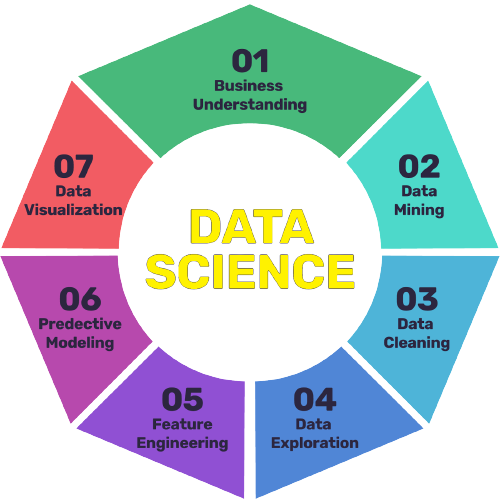

## Index

1. Business Understanding
2. Data Gathering
3. Data Cleaning
4. Data Exploration
   - Finding yearly average and calculating Heat level using yearly average temperature
   - Analyzing Average, Minimum and Maximum Temperature since Year 1800
   - Analyzing data trend using Linear Regression, Polynomial Regression, Correlation Matrix, Random Forest, XGBoost and Nearest neighbors
5. Feature Engineering
   - Attempt to minimize the MED
   - Features importance
   - Adding New variables and decreasing of the MED
6. Predictive Data Modeling
   - Random Forest
   - XGBoost
7. Clustering
   - Country Clustering
   - 1st Clustering
   - 2nd Clustering
8. Data Visualization
   - Conclusion on multiple cities
   - Growth of global Fossil fuels consumption
   - Global mean sea levels over years
   - Does the rise in average temperature related to global higher temperatures?
   - Hottest Year on Record?
   - Hottest Decade on Record?
   - Are global sea levels rising?
   - Is ocean warming real? If true then show temperatures per decade over the past 100 years
   - Annual Per capita CO2 emissions
   - Total carbon footprint
   - Carbon emissions from 2000 to 2010 from different sources
   - Surface maximum and minimum temperature over 5 years
   - How much global average surface temperature has increased since 1880?
   - Is sea level rising? If yes then show change in global sea levels
   - Main sources of Carbon emissions
   - Ocean's rate of heating?
9. Inferences and Conclusion

## Business Understanding

[figure not shown]

Climate change is one of the important issues that face the world in this technological era. The best proof of this situation is the historical temperature change (It is shown in left figure(https://ocw.mit.edu/courses/comparative-media-studies-writing/cms-631-data-storytelling-studio-climate-change-spring-2017/#)).  
This Case study investigates the reality of the increase in temperatures linked to industrial activities and the greenhouse effect. And before this investigation, the aim of this part enlight the significant sides of the temperature change data for each area. Before beginning the analysis, firstly, I want to figure out our problem, its cause and its effects in a short way.

#### What is Climate Change?

"*Climate change is a long-term change in the average weather patterns that have come to define Earth’s local, regional and global climates. Changes observed in Earth’s climate since the early 20th century are primarily driven by human activities, particularly fossil fuel burning, which increases heat-trapping greenhouse gas levels in Earth’s atmosphere, raising Earth’s average surface temperature. These human-produced temperature increases are commonly referred to as global warming.*"

##### Causes

"*According to NASA, Water Vapour, Carbon dioxide(CO₂), Methane, Nitrous oxide, Chlorofluorocarbons(CFCs) contribute to the greenhouse effect. Over the last century, human activities have increased concentrations of this natural greenhouse.*"

##### Effects:

"*Global climate change has already had observable effects on the environment. Glaciers have shrunk, ice on rivers and lakes is breaking up earlier, plant and animal ranges have shifted, and trees are flowering sooner. Effects that scientists had predicted in the past would result from global climate change: loss of sea ice accelerated sea-level rise and longer, more intense heat waves.*(https://climate.nasa.gov/effects/)"

This section mainly covers defining goals of this case study and understanding its requirements

#### Goals of this project:

1. Analysing historical global min-max-mean temprature from land and ocean
2. Predicting global average temprature using various machine learning models
3. Analysing climate change in Paris using historical paris temprature
4. Visualizing cause(via AQI) and affect(rising sea level) of climate change

#### Importing Python libraries neccessary for this case study

```python
import pandas as pd
from pandas import Series, DataFrame
pd.options.mode.chained_assignment = None

import numpy as np
import matplotlib.pyplot as plt
plt.rcParams['axes.facecolor'] = 'white'
import seaborn as sns
import matplotlib.dates as mdates
import bokeh as bk
sns.set_style('whitegrid')
%matplotlib inline
import copy

# machine learning sklearn
from sklearn.model_selection import train_test_split
from sklearn import linear_model
from sklearn import metrics
from sklearn.svm import SVC, LinearSVC
from sklearn.ensemble import RandomForestClassifier
from sklearn.ensemble import RandomForestRegressor
from sklearn.neighbors import KNeighborsClassifier
from sklearn.naive_bayes import GaussianNB
from sklearn.neighbors import KNeighborsRegressor
import xgboost
from xgboost import XGBRegressor

from bokeh.plotting import figure, show
from bokeh.models import ColumnDataSource, Circle, HoverTool, CustomJS
from bokeh.io import output_notebook
```

## Data Gathering

There are 6 files used for this case study. Source: http://berkeleyearth.org/data/

1. GlobalTemperatures.csv
2. GlobalLandTemperaturesByMajorCity.csv
3. GlobalLandTemperaturesByCountry.csv
4. co2-mm-mlo.csv
5. global_co2.csv
6. CSIRO_gmsl.csv

Global Land and Ocean-and-Land Temperatures (GlobalTemperatures.csv):

- **Date**: starts in 1750 for average land temperature and 1850 for max and min land temperatures and global ocean and land temperatures
- **LandAverageTemperature**: global average land temperature in celsius
- **LandAverageTemperatureUncertainty**: the 95% confidence interval around the average
- **LandMaxTemperature**: global average maximum land temperature in celsius
- **LandMaxTemperatureUncertainty**: the 95% confidence interval around the maximum land temperature
- **LandMinTemperature**: global average minimum land temperature in celsius
- **LandMinTemperatureUncertainty**: the 95% confidence interval around the minimum land temperature
- **LandAndOceanAverageTemperature**: global average land and ocean temperature in celsius
- **LandAndOceanAverageTemperatureUncertainty**: the 95% confidence interval around the global average land and ocean temperature

GlobalLandTemperaturesByMajorCity.csv:

- **dt**: Date
- **AverageTemperature**: Global average land and ocean temperature in celsius
- **AverageTemperatureUncertainty**: The 95% confidence interval around the average
- **City**: City Name
- **Country**: Country Name
- **Latitude**: Latitude coordinate
- **Longitude**: Longitude coordinate

GlobalLandTemperaturesByCountry.csv:

- **dt**: Date
- **AverageTemperature**: Global average land and ocean temperature in celsius
- **AverageTemperatureUncertainty**: tThe 95% confidence interval around the average
- **Country**: Country Name

co2-mm-mlo.csv:

- **Date**: Date
- **Decimal Date**: Date in decimal
- **Average**: The monthly mean CO2 mole fraction determined from daily averages. If there are missing days concentrated either early or late in the month, the monthly mean is corrected to the middle of the month using the average seasonal cycle. Missing months are denoted by -99.99.
- **Interpolated**: Values from the average column and interpolated values where data are missing. Interpolated values are computed in two steps. First, we compute for each month the average seasonal cycle in a 7-year window around each monthly value. In this way the seasonal cycle is allowed to change slowly over time. We then determine the trend value for each month by removing the seasonal cycle; this result is shown in the trend column. Trend values are linearly interpolated for missing months. The interpolated monthly mean is then the sum of the average seasonal cycle value and the trend value for the missing month.
- **Trend**: Seasonally corrected Trends in Atmospheric Carbon Dioxide
- **Number of Days**: -1 denotes no data for number of daily averages in the month.

CSIRO_gmsl.csv:

- **Time**: Date
- **GMSL (mm)**: Annual Global Mean Sea Levels
- **GMSL uncertainty (mm)**: Uncertainity in Annual Global Mean Sea Levels

global_co2.csv:

- **Time**
- **Total carbon emissions from fossil fuel consumption and cement production (mil. metric tons of C)**
- **Carbon emissions from gas fuel consumption**
- **Carbon emissions from liquid fuel consumption**
- **Carbon emissions from solid fuel consumption**
- **Carbon emissions from cement production Carbon emissions from gas flaring**
- **Per capita carbon emissions (metric tons of carbon; after 1949 only)**

```python
# get global temp csv file as a DataFrame
global_temps = pd.read_csv("GlobalTemperatures.csv", sep=',')
global_temps2 = copy.deepcopy(global_temps)
global_temps.tail()
```

|  | dt | LandAverageTemperature | LandAverageTemperatureUncertainty | LandMaxTemperature | LandMaxTemperatureUncertainty | LandMinTemperature | LandMinTemperatureUncertainty | LandAndOceanAverageTemperature | LandAndOceanAverageTemperatureUncertainty |
| --- | --- | --- | --- | --- | --- | --- | --- | --- | --- |
| 3187 | 2015-08-01 | 14.755 | 0.072 | 20.699 | 0.110 | 9.005 | 0.170 | 17.589 | 0.057 |
| 3188 | 2015-09-01 | 12.999 | 0.079 | 18.845 | 0.088 | 7.199 | 0.229 | 17.049 | 0.058 |
| 3189 | 2015-10-01 | 10.801 | 0.102 | 16.450 | 0.059 | 5.232 | 0.115 | 16.290 | 0.062 |
| 3190 | 2015-11-01 | 7.433 | 0.119 | 12.892 | 0.093 | 2.157 | 0.106 | 15.252 | 0.063 |
| 3191 | 2015-12-01 | 5.518 | 0.100 | 10.725 | 0.154 | 0.287 | 0.099 | 14.774 | 0.062 |

```python
global_temps.info()
```

```
<class 'pandas.core.frame.DataFrame'>
RangeIndex: 3192 entries, 0 to 3191
Data columns (total 9 columns):
 #   Column                                     Non-Null Count  Dtype
---  ------                                     --------------  -----
 0   dt                                         3192 non-null   object
 1   LandAverageTemperature                     3180 non-null   float64
 2   LandAverageTemperatureUncertainty          3180 non-null   float64
 3   LandMaxTemperature                         1992 non-null   float64
 4   LandMaxTemperatureUncertainty              1992 non-null   float64
 5   LandMinTemperature                         1992 non-null   float64
 6   LandMinTemperatureUncertainty              1992 non-null   float64
 7   LandAndOceanAverageTemperature             1992 non-null   float64
 8   LandAndOceanAverageTemperatureUncertainty  1992 non-null   float64
dtypes: float64(8), object(1)
memory usage: 224.6+ KB
```

### Analysis

**There are 9 columns and there are 12 rows with all null values. We will drop these rows and unneccesary columns**

## Data Cleaning

```python
# Delete all columns except dates, Land Average Temperatures, Land Average Temperature Uncertainty
global_temps=global_temps.drop(global_temps.columns[3:], axis=1)

#Delete all empty lines
global_temps=global_temps.dropna()
```

```python
global_temps.info()
```

```
<class 'pandas.core.frame.DataFrame'>
Int64Index: 3180 entries, 0 to 3191
Data columns (total 3 columns):
 #   Column                             Non-Null Count  Dtype
---  ------                             --------------  -----
 0   dt                                 3180 non-null   object
 1   LandAverageTemperature             3180 non-null   float64
 2   LandAverageTemperatureUncertainty  3180 non-null   float64
dtypes: float64(2), object(1)
memory usage: 99.4+ KB
```

```python
global_temps.describe()
```

|  | LandAverageTemperature | LandAverageTemperatureUncertainty |
| --- | --- | --- |
| count | 3180.000000 | 3180.000000 |
| mean | 8.374731 | 0.938468 |
| std | 4.381310 | 1.096440 |
| min | -2.080000 | 0.034000 |
| 25% | 4.312000 | 0.186750 |
| 50% | 8.610500 | 0.392000 |
| 75% | 12.548250 | 1.419250 |
| max | 19.021000 | 7.880000 |

## Data Exploration

### Finding yearly average and calculating Heat level using yearly average temperature

```python
df = copy.deepcopy(global_temps)
df['dt'] = df['dt'].apply(lambda x: x[:4])
df_global_mean = df.groupby(['dt']).agg({'LandAverageTemperature': np.mean,
                             'LandAverageTemperatureUncertainty': np.mean})

#Defining a function that classifies the average temperatures
def heat(x):

    if type(x) is str:
        return x
    elif x<=7:
        return 3
    elif x>7 and x<=8:
        return 2
    else:
        return 1

#Adding the heat function
df_global_mean['Heat'] = df_global_mean['LandAverageTemperature'].apply(heat)
df_global_mean.reset_index(inplace=True)
df_global_mean.rename(columns = {'LandAverageTemperature':'Temperatures',
                      'LandAverageTemperatureUncertainty':'Uncertainty',
                      'dt':'Dates'}, inplace = True)
print(df_global_mean.head())
```

```
  Dates  Temperatures  Uncertainty  Heat
0  1750      8.719364     2.637818     1
1  1751      7.976143     2.781143     2
2  1752      5.779833     2.977000     3
3  1753      8.388083     3.176000     1
4  1754      8.469333     3.494250     1
```

```python
print(str(max(df_global_mean['Dates'])), str(min(df_global_mean['Dates'])))
```

```
2015 1750
```

```python
#Global Average Temperatures plot using Bokeh

output_notebook()
tools_to_show = 'box_zoom,save,hover,reset'
t = "Evolution of average global land temperatures from 1750 to 2015"
p = figure(title=t, x_axis_label='Dates', y_axis_label='Temperatures', tools=tools_to_show)
p.scatter(x='Dates', y='Temperatures', source=df_global_mean)
show(p)
```

[interactive chart not shown]

### Analysis

**As we can clearly see global mean temprature is increasing at a very high rate as year passes.**

```python
#Now, we plot the 95% Uncertainty regarding the temperature evolution
output_notebook()
tools_to_show = 'box_zoom,save,hover,reset'
(x, y) = (df_global_mean['Dates'], df_global_mean['Uncertainty'])

# Basic plot setup
p = figure(width=800, height=600, toolbar_location=None,
           title='A clear decreasing of uncertainty')

p.line(x, y, line_dash="4 4", line_width=1, color='gray')


# Add a circle, that is visible only when selected
source = ColumnDataSource({'x': x, 'y': y})
invisible_circle = Circle(x='x', y='y', fill_color='gray', fill_alpha=0.05, line_color=None, size=20)
visible_circle = Circle(x='x', y='y', fill_color='firebrick', fill_alpha=0.5, line_color=None, size=20)
cr = p.add_glyph(source, invisible_circle, selection_glyph=visible_circle, nonselection_glyph=invisible_circle)

# Add a hover tool, that selects the circle
code = "source.set('selected', cb_data['index']);"
callback = CustomJS(args={'source': source}, code=code)
p.add_tools(HoverTool(tooltips=None, callback=callback, renderers=[cr], mode='hline'))

show(p)
```

[interactive chart not shown]

### Analysis

**As we can clearly see global mean Uncertainty Temprature is decreasing at a very high rate as year passes.**

```python
global_temps2.info()
```

```
<class 'pandas.core.frame.DataFrame'>
RangeIndex: 3192 entries, 0 to 3191
Data columns (total 9 columns):
 #   Column                                     Non-Null Count  Dtype
---  ------                                     --------------  -----
 0   dt                                         3192 non-null   object
 1   LandAverageTemperature                     3180 non-null   float64
 2   LandAverageTemperatureUncertainty          3180 non-null   float64
 3   LandMaxTemperature                         1992 non-null   float64
 4   LandMaxTemperatureUncertainty              1992 non-null   float64
 5   LandMinTemperature                         1992 non-null   float64
 6   LandMinTemperatureUncertainty              1992 non-null   float64
 7   LandAndOceanAverageTemperature             1992 non-null   float64
 8   LandAndOceanAverageTemperatureUncertainty  1992 non-null   float64
dtypes: float64(8), object(1)
memory usage: 224.6+ KB
```

```python
global_temps2.head()
```

|  | dt | LandAverageTemperature | LandAverageTemperatureUncertainty | LandMaxTemperature | LandMaxTemperatureUncertainty | LandMinTemperature | LandMinTemperatureUncertainty | LandAndOceanAverageTemperature | LandAndOceanAverageTemperatureUncertainty |
| --- | --- | --- | --- | --- | --- | --- | --- | --- | --- |
| 0 | 1750-01-01 | 3.034 | 3.574 | NaN | NaN | NaN | NaN | NaN | NaN |
| 1 | 1750-02-01 | 3.083 | 3.702 | NaN | NaN | NaN | NaN | NaN | NaN |
| 2 | 1750-03-01 | 5.626 | 3.076 | NaN | NaN | NaN | NaN | NaN | NaN |
| 3 | 1750-04-01 | 8.490 | 2.451 | NaN | NaN | NaN | NaN | NaN | NaN |
| 4 | 1750-05-01 | 11.573 | 2.072 | NaN | NaN | NaN | NaN | NaN | NaN |

```python
date=global_temps2['dt'].apply(lambda x: x[:4])

global_temps2['dt'] = global_temps2['dt'].apply(lambda x: x[:4])
years=np.unique(global_temps2['dt'])
list_of_years_1800 = list(filter(lambda x: int(x) >= 1800, years))
global_temps2['dt'] = pd.to_numeric(global_temps2['dt'])
global_temps2.drop(global_temps2[global_temps2.dt < 1800].index, inplace=True)
global_temps_1800 = global_temps2.groupby(['dt']).agg({'LandAverageTemperature': np.mean,
                                         'LandMinTemperature': np.mean,
                                         'LandMaxTemperature': np.mean})
global_temps_1800.reset_index(inplace=True)
global_temps_1800.rename(columns = {'LandAverageTemperature':'Average Temperature',
                      'LandMinTemperature':'Min Temperature',
                      'LandMaxTemperature':'Max Temperature',
                      'dt':'Dates'}, inplace = True)
global_temps_1800.head(5)
```

|  | Dates | Average Temperature | Min Temperature | Max Temperature |
| --- | --- | --- | --- | --- |
| 0 | 1800 | 8.484250 | NaN | NaN |
| 1 | 1801 | 8.589667 | NaN | NaN |
| 2 | 1802 | 8.578167 | NaN | NaN |
| 3 | 1803 | 8.503000 | NaN | NaN |
| 4 | 1804 | 8.844833 | NaN | NaN |

### Analyzing Average, Minimum and Maximum Temprature since Year 1800

```python
output_notebook()

x = global_temps_1800['Dates']
y = global_temps_1800['Average Temperature']
z = global_temps_1800['Min Temperature']
t = global_temps_1800['Max Temperature']

p = figure(plot_width=600, plot_height=600)

p.line(x, y, legend_label="Average Temperature", line_color="green", line_width=3)

p.line(x,z, legend_label="Min Temperature", line_color="blue", line_width=3)

p.line(x, t, legend_label="Max Temperature", line_color="red", line_width=3)

# change just some things about the x-grid
p.xgrid.band_fill_alpha = 0.05
p.xgrid.band_fill_color = "navy"

p.legend.location = "top_left"
p.legend.glyph_width = 2
p.legend.label_width=2
show(p)
```

[interactive chart not shown]

### Analysis

**As we can clearly see global average, minimum and maximum temprature is increasing at a very high rate as year passes.**

### Linear Regression

#### X = years Y = Average Temprature

```python
#Regression on all the data (without prediction) => See if a regression can be a good estimation

#Define the input and output
temp=global_temps_1800['Average Temperature']
time=global_temps_1800['Dates']
# The data sets
dates_X = time.iloc[0:,]
print("X = \n")
print(dates_X[:5])
# The targets
temperature_y = temp.iloc[0:,]
print("Y = \n")
print(temperature_y[:5])
```

```
X =

0    1800
1    1801
2    1802
3    1803
4    1804
Name: Dates, dtype: int64
Y =

0    8.484250
1    8.589667
2    8.578167
3    8.503000
4    8.844833
Name: Average Temperature, dtype: float64
```

```python
# Create linear regression object
reg = linear_model.LinearRegression()
# Train the model using the data sets
reg.fit(dates_X.to_frame(),temperature_y.to_frame())

# The estimation
output_reg=reg.predict(dates_X.to_frame())
output_simple=np.copy(output_reg)
output=pd.DataFrame(index=pd.DataFrame(output_simple).index.values)
# The coefficients
print('Coefficients: \n', reg.coef_)
# The intercept
print('Intercept: \n', reg.intercept_)
# The mean squared error
print("Mean squared error: %.2f" % np.mean((reg.predict(dates_X.to_frame()) - temperature_y.to_frame()) ** 2))
# Explained variance score: 1 is perfect prediction
print('Variance score: %.2f' % reg.score(dates_X.to_frame(), temperature_y.to_frame()))
```

```
Coefficients:
 [[0.00721859]]
Intercept:
 [-5.35578585]
Mean squared error: 0.12
Variance score: 0.64
```

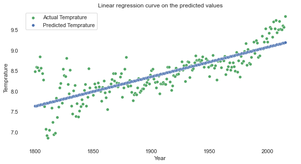

```python
sns.set(rc={'axes.facecolor':'white', 'figure.facecolor':'white'})
date_temp = pd.DataFrame({'dates_X':dates_X, 'temperature_y':temperature_y})
date_output = pd.DataFrame({'dates_X':dates_X, 'output_simple':output_simple.ravel().tolist()})
fig, ax = plt.subplots(figsize=(10,5))
actual = sns.scatterplot(x='dates_X', y='temperature_y', data=date_temp, color='g',
                      label='Actual Temprature')
predicted = sns.scatterplot(x='dates_X', y='output_simple', data=date_output, color='b',
                         label='Predicted Temprature')
plt.xlabel("Year")
plt.ylabel("Temprature")
plt.title("Linear regression curve on the predicted values")
plt.legend()
plt.show()
```

### Linear Regression

#### X = years Y = Average Temprature

```python
dates_X_train, dates_X_test, temperature_y_train, temperature_y_test = train_test_split(time,
                                                                        temp,
                                                                        test_size = 0.32,
                                                                        random_state = 0,
                                                                        shuffle = False)
reg = linear_model.LinearRegression()
reg.fit(dates_X_train.to_frame(),temperature_y_train.to_frame())
# Create linear regression object
reg = linear_model.LinearRegression()

# Train the model using the training sets
reg.fit(dates_X_train.to_frame(),temperature_y_train.to_frame())

# The coefficients
print('Coefficients: \n', reg.coef_)
# The intercept
print('Intercept: \n', reg.intercept_)

# The prediction
output_simple=reg.predict(dates_X_test.to_frame())
# The mean squared error
print("Mean squared error: %.2f"
      % np.mean((reg.predict(dates_X_test.to_frame()) - temperature_y_test.to_frame()) ** 2))
# Explained variance score: 1 is perfect prediction
print('Variance score: %.2f' % reg.score(dates_X_test.to_frame(), temperature_y_test.to_frame()))
```

```
Coefficients:
 [[0.00557041]]
Intercept:
 [-2.27932684]
Mean squared error: 0.14
Variance score: 0.13
```

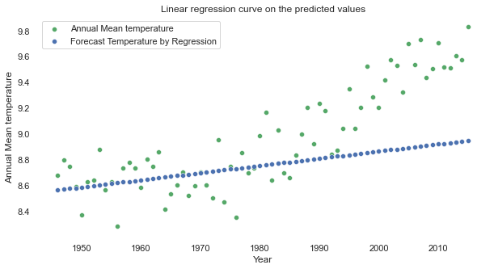

```python
sns.set(rc={'axes.facecolor':'white', 'figure.facecolor':'white'})
date_temp_test = pd.DataFrame({'dates_X_test':dates_X_test, 'temperature_y_test':temperature_y_test})
date_output_test = pd.DataFrame({'dates_X_test':dates_X_test, 'output_simple':output_simple.ravel().tolist()})
fig, ax = plt.subplots(figsize=(10,5))
actual = sns.scatterplot(x='dates_X_test', y='temperature_y_test', data=date_temp_test, color='g', label='Annual Mean temperature')
predicted = sns.scatterplot(x='dates_X_test', y='output_simple', data=date_output_test, color='b', label='Forecast Temperature by Regression')
plt.xlabel("Year")
plt.ylabel("Annual Mean temperature")
plt.title("Linear regression curve on the predicted values")
plt.legend()
plt.show()
```

### Analysis

**As we can clearly see global average temprature is increasing at a rate far from predicted rate since 1990**

### Polynomial Regression

```python
#Polynomial Regression t^2 + t^3

#Regression on all the data (without prediction) => See if a regression can be a good estimation

#Define the input and output
time=pd.DataFrame()
time["Dates"]=global_temps_1800['Dates']
time["Dates^2"]=global_temps_1800['Dates']*global_temps_1800['Dates']
time["Dates^3"]=global_temps_1800['Dates']*global_temps_1800['Dates']*global_temps_1800['Dates']
temp=global_temps_1800['Average Temperature']


# The data sets
dates_X = time.iloc[0:,0]

# The targets
temperature_y = temp.iloc[0:,]

# Create linear regression object
reg = linear_model.LinearRegression()

# Train the model using the training sets
reg.fit(time.iloc[0:,],temperature_y.to_frame())

# The prediction
output_reg=reg.predict(time.iloc[0:,])
output_multiple=np.copy(output_reg)
output=pd.DataFrame(index=pd.DataFrame(output_simple).index.values)
# The coefficients
print('Coefficients: \n', reg.coef_)
# The intercept
print('Intercept: \n', reg.intercept_)

# The mean squared error
print("Mean squared error: %.2f" % np.mean((output_reg - temperature_y.to_frame()) ** 2))

# Explained variance score: 1 is perfect prediction
print('Variance score: %.2f' % reg.score(time.iloc[0:,], temperature_y.to_frame()))

# Euclidian Distance
output['Predicted Temperature']=pd.DataFrame(output_multiple)
output["Average Temperature"]=temp
```

```
Coefficients:
 [[ 1.54583760e+00 -8.43972200e-04  1.53912499e-07]]
Intercept:
 [-937.81103858]
Mean squared error: 0.10
Variance score: 0.69
```

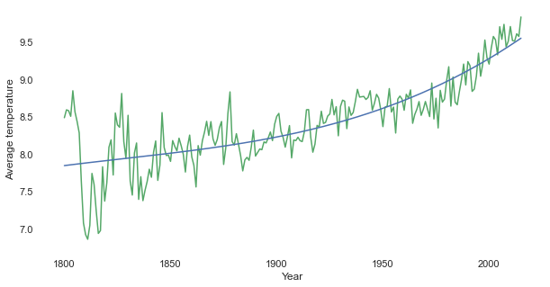

```python
# Linear regression curve on the predicted values

# Multiple Linear Regression: t,t^2, t^3: Regression done on the values between 1800 and 1950 and testes between 1950 and 2016
fig, axes = plt.subplots(figsize=(10,5))
axes.set_ylabel('Average temperature', fontsize=12)
axes.set_xlabel('Year', fontsize=12)
plt.plot(dates_X, temperature_y, label='Annual Mean temperature', color='g')
plt.plot(dates_X,output_multiple,label='Forecast Reg',color='b')
```

```python
#Polynomial Regression t^2 + t^3

#Define the input and output
temp=global_temps_1800['Average Temperature']
time=pd.DataFrame()
time["Dates"]=global_temps_1800['Dates']
time["Dates^2"]=global_temps_1800['Dates']*global_temps_1800['Dates']
time["Dates^3"]=global_temps_1800['Dates']*global_temps_1800['Dates']*global_temps_1800['Dates']

dates_X_train, dates_X_test, temperature_y_train, temperature_y_test = train_test_split(time,
                                                                        temp,
                                                                        test_size = 0.32,
                                                                        random_state = 0,
                                                                        shuffle = False)

# Create linear regression object
reg = linear_model.LinearRegression()
# Train the model using the training sets
reg.fit(dates_X_train,temperature_y_train.to_frame())
# The coefficients
print('Coefficients: \n', reg.coef_)
# The intercept
print('Intercept: \n', reg.intercept_)
# The prediction
output_multiple=reg.predict(dates_X_test)
# The mean squared error
print("Mean squared error: %.2f"
      % np.mean((reg.predict(dates_X_test) - temperature_y_test.to_frame()) ** 2))
# Explained variance score: 1 is perfect prediction
print('Variance score: %.2f' % reg.score(dates_X_test, temperature_y_test.to_frame()))
```

```
Coefficients:
 [[-3.19371602e+00  1.65731673e-03 -2.85817763e-07]]
Intercept:
 [2053.84193735]
Mean squared error: 0.08
Variance score: 0.47
```

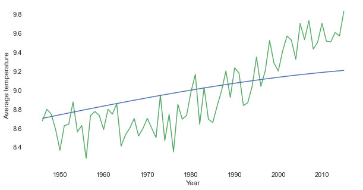

```python
# Linear regression curb on the predicted values

# Multiple Linear Regression: t,t^2, t^3: Regression done on the values between 1800 and 1950 and testes between 1950 and 2016
fig, axes = plt.subplots(figsize=(10,5))
axes.set_ylabel('Average temperature', fontsize=12)
axes.set_xlabel('Year', fontsize=12)
#
plt.plot(dates_X_test.iloc[:,0], temperature_y_test, label='Annual Mean temperature', color='g')
plt.plot(dates_X_test.iloc[:,0], output_multiple, label='Forecast Reg',color='b')
```

### Analysis

**As we can clearly see global average temprature is increasing at a rate far from predicted rate since 1990**

### Correlation Matrix

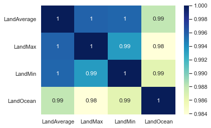

```python
#Correlation Matrix for the following features : LandAverageTemperature, LandMaxTemperature, LandMinTemperature,LandAndOceanAverageTemperature

global_temperatures=pd.read_csv("GlobalTemperatures.csv", sep=',')
global_temperatures['dt'] = pd.to_datetime(global_temperatures['dt'])
global_temperatures = global_temperatures.drop(["LandAverageTemperatureUncertainty",
                                                "LandMaxTemperatureUncertainty",
                                                "LandMinTemperatureUncertainty",
                                                "LandAndOceanAverageTemperatureUncertainty"], axis=1)
global_temperatures=global_temperatures.dropna()
corr=global_temperatures.corr()

# Heatmap for the previous correlation matrix
sns.heatmap(corr,xticklabels=['LandAverage','LandMax','LandMin','LandOcean'],
            yticklabels=['LandAverage','LandMax','LandMin','LandOcean'], annot=True, cmap="YlGnBu")
```

```python
print("Minimum year:", global_temperatures['dt'].map(lambda x: x.year).min())
print("Maximum year:", global_temperatures['dt'].map(lambda x: x.year).max())
```

```
Minimum year: 1850
Maximum year: 2015
```

### Random Forest

Using temprature data before year 1980 to predict temprature from 1980 to 2015

```python
# Train
train_df_copy=pd.DataFrame.copy(
    global_temperatures[global_temperatures['dt'].map(lambda x: x.year)<1980])
train_df=pd.DataFrame.copy(train_df_copy)
train_df.drop(train_df.index[:1], inplace=True)
train_df_copy.drop(train_df.index[-1],inplace=True)

# To predict each average land temperature we use the previous year's temperatures (landandocean, min, max)
for j in (train_df.index):
    for column in train_df.columns[1:-1]:
        train_df.loc[j,column]=train_df_copy.loc[j-1,column]

train_df.head(5)
```

|  | dt | LandAverageTemperature | LandMaxTemperature | LandMinTemperature | LandAndOceanAverageTemperature |
| --- | --- | --- | --- | --- | --- |
| 1201 | 1850-02-01 | 0.749 | 8.242 | -3.206 | 13.588 |
| 1202 | 1850-03-01 | 3.071 | 9.970 | -2.291 | 14.043 |
| 1203 | 1850-04-01 | 4.954 | 10.347 | -1.905 | 14.667 |
| 1204 | 1850-05-01 | 7.217 | 12.934 | 1.018 | 15.507 |
| 1205 | 1850-06-01 | 10.004 | 15.655 | 3.811 | 16.353 |

```python
# Test
test_df_copy=pd.DataFrame.copy(
    global_temperatures[global_temperatures['dt'].map(lambda x: x.year)>=1980])
test_df=pd.DataFrame.copy(test_df_copy)
test_df.drop(test_df.index[:1], inplace=True)
test_df_copy.drop(test_df.index[-1], inplace=True)

# To predict each average land temperature we use the previous year's temperatures (landandocean, min , max)
for j in (test_df.index):
    for column in test_df.columns[1:-1]:
        test_df.loc[j,column]=test_df_copy.loc[j-1,column]
test_df=test_df.drop(['dt'],axis=1)
test_df.head(5)
```

|  | LandAverageTemperature | LandMaxTemperature | LandMinTemperature | LandAndOceanAverageTemperature |
| --- | --- | --- | --- | --- |
| 2761 | 2.956 | 8.468 | -2.457 | 14.112 |
| 2762 | 3.652 | 9.260 | -1.864 | 14.646 |
| 2763 | 5.367 | 11.240 | -0.379 | 15.578 |
| 2764 | 8.935 | 14.821 | 3.109 | 16.314 |
| 2765 | 11.770 | 17.713 | 6.131 | 16.806 |

```python
forest = RandomForestRegressor(n_estimators=10)
train_df=train_df.drop(['dt'],axis=1)
forest = forest.fit(train_df.drop(["LandAverageTemperature"],axis=1),train_df["LandAverageTemperature"])
```

```python
y_test = test_df['LandAverageTemperature']
y_pred = forest.predict(test_df.drop(["LandAverageTemperature"],axis=1))
```

```python
#Adding the predicted temperature to our output DF
test_df['Predicted_temp']=y_pred
```

```python
print('Mean Euclidean Distance:',abs(y_test-y_pred).mean())
print('Mean Absolute Error:', metrics.mean_absolute_error(y_test, y_pred))
print('Mean Squared Error:', metrics.mean_squared_error(y_test, y_pred))
print('Root Mean Squared Error:', np.sqrt(metrics.mean_squared_error(y_test, y_pred)))
print('R2 Square:', metrics.r2_score(y_test, y_pred))
```

```
Mean Euclidean Distance: 0.23060185614849205
Mean Absolute Error: 0.23060185614849207
Mean Squared Error: 0.10328745443155467
Root Mean Squared Error: 0.3213836561363298
R2 Square: 0.9939579096296686
```

### XGBoost

```python
# Train
train_df_copy_2=pd.DataFrame.copy(global_temperatures[global_temperatures['dt'].map(lambda x: x.year)<1980])
train_df_2=pd.DataFrame.copy(train_df_copy_2)
train_df_2.drop(train_df_2.index[:1], inplace=True)
train_df_copy_2.drop(train_df_2.index[-1], inplace=True)

# To predict each average land temperature we use the previous year's temperatures (landandocean, min , max)
for j in (train_df_2.index):
    for column in train_df_2.columns[1:-1]:
        train_df_2.loc[j,column]=train_df_copy_2.loc[j-1,column]
xgbr = XGBRegressor()
train_df_2=train_df_2.drop(['dt'],axis=1)
xgbr = xgbr.fit(train_df_2.drop(["LandAverageTemperature"],axis=1),train_df_2["LandAverageTemperature"])
```

```python
# Test
test_df_copy_2=pd.DataFrame.copy(global_temperatures[global_temperatures['dt'].map(lambda x: x.year)>=1980])
test_df_2=pd.DataFrame.copy(test_df_copy_2)
test_df_2.drop(test_df_2.index[:1], inplace=True)
test_df_copy_2.drop(test_df_2.index[-1], inplace=True)
# To predict each average land temperature we use the previous year's temperatures (landandocean, min , max)
for j in (test_df_2.index):
    for column in test_df_2.columns[1:-1]:
        test_df_2.loc[j,column]=test_df_copy_2.loc[j-1,column]
test_df_2=test_df_2.drop(['dt'],axis=1)
y_test = test_df_2['LandAverageTemperature']
y_pred = xgbr.predict(test_df_2.drop(["LandAverageTemperature"],axis=1))
```

```python
# Adding the predicted temperature to our output DF
test_df_2['Predicted_temp']=y_pred
```

```python
print('Mean Euclidean Distance:',abs(y_test-y_pred).mean())
print('Mean Absolute Error:', metrics.mean_absolute_error(y_test, y_pred))
print('Mean Squared Error:', metrics.mean_squared_error(y_test, y_pred))
print('Root Mean Squared Error:', np.sqrt(metrics.mean_squared_error(y_test, y_pred)))
print('R2 Square:', metrics.r2_score(y_test, y_pred))
```

```
Mean Euclidean Distance: 0.24781643837399955
Mean Absolute Error: 0.24781643837399941
Mean Squared Error: 0.11480838462418805
Root Mean Squared Error: 0.3388338599139526
R2 Square: 0.9932839603900704
```

### Nearest neighbors

```python
# Train
neigh = KNeighborsRegressor(n_neighbors=2)
train_df_copy_3=pd.DataFrame.copy(global_temperatures[global_temperatures['dt'].map(lambda x: x.year)<1980])
train_df_3=pd.DataFrame.copy(train_df_copy_3)
train_df_3.drop(train_df_3.index[:1], inplace=True)
train_df_copy_3.drop(train_df_3.index[-1], inplace=True)

# To predict each average land temperature we use the previous year's temperatures (landandocean, min , max)
for j in (train_df_3.index):
    for column in train_df_3.columns[1:-1]:
        train_df_3.loc[j,column]=train_df_copy_3.loc[j-1,column]
train_df_3=train_df_3.drop(['dt'],axis=1)
neighbors=neigh.fit(train_df_3.drop(["LandAverageTemperature"],axis=1),train_df_3["LandAverageTemperature"])
```

```python
# Test
test_df_copy_3=pd.DataFrame.copy(global_temperatures[global_temperatures['dt'].map(lambda x: x.year)>=1980])
test_df_3=pd.DataFrame.copy(test_df_copy_3)
test_df_3.drop(test_df_3.index[:1], inplace=True)
test_df_copy_3.drop(test_df_3.index[-1], inplace=True)

# To predict each average land temperature we use the previous year's temperatures (landandocean, min , max)
for j in (test_df_3.index):
    for column in test_df_3.columns[1:-1]:
        test_df_3.loc[j,column]=test_df_copy_3.loc[j-1,column]
test_df_3=test_df_3.drop(['dt'],axis=1)
y_test = test_df_3['LandAverageTemperature']
y_pred = neigh_output = neighbors.predict(test_df_3.drop(["LandAverageTemperature"],axis=1))
```

```python
# Adding the predicted temperature to our output DF
test_df_3['Predicted_temp']=neigh_output
```

```python
print('Mean Euclidean Distance:',abs(y_test-y_pred).mean())
print('Mean Absolute Error:', metrics.mean_absolute_error(y_test, y_pred))
print('Mean Squared Error:', metrics.mean_squared_error(y_test, y_pred))
print('Root Mean Squared Error:', np.sqrt(metrics.mean_squared_error(y_test, y_pred)))
print('R2 Square:', metrics.r2_score(y_test, y_pred))
```

```
Mean Euclidean Distance: 0.23760904872389793
Mean Absolute Error: 0.23760904872389793
Mean Squared Error: 0.11978698433874707
Root Mean Squared Error: 0.346102563322994
R2 Square: 0.992992723186495
```

## Feature Engineering

### Attempt to minimize the MED

```python
#Definition of the function we want to minimize

def MED_XGB(n,maxi,learn,
       X_train, y_train, X_test,y_test,
       MED_limit):

    '''
    n         : n_estimators  -> Number of boosted trees to fit
    maxi      : max_depth     -> Maximum tree depth for base learners
    learn     : learning_rate -> Boosting learning rate
    ...
    MED_limit : -> threshold for minimum MED required
    '''

    xgb_model = xgboost.XGBRegressor(n_estimators = n , learning_rate = learn, max_depth = maxi )
    model_fit = xgb_model.fit(X_train , y_train )
    y_predict = model_fit.predict(X_test)
    MED=abs(y_test-y_predict).mean()

    if MED<MED_limit:
        return MED , n, learn, maxi
    else:
        return 0
```

```python
#### Data Sets ####

#Train
train_df_copy=pd.DataFrame.copy(global_temperatures[global_temperatures['dt'].map(lambda x: x.year)<1980])
train_df=pd.DataFrame.copy(train_df_copy)
train_df.drop(train_df.index[:1], inplace=True)
train_df_copy.drop(train_df.index[-1], inplace=True)
for j in (train_df.index):
    for column in train_df.columns[1:-1]:
        train_df.loc[j,column]=train_df_copy.loc[j-1,column]

train_df=train_df.drop(['dt'],axis=1)

#Test
test_df_copy=pd.DataFrame.copy(global_temperatures[global_temperatures['dt'].map(lambda x: x.year)>=1980])
test_df=pd.DataFrame.copy(test_df_copy)
test_df.drop(test_df.index[:1], inplace=True)
test_df_copy.drop(test_df.index[-1], inplace=True)
for j in (test_df.index):
    for column in test_df.columns[1:-1]:
        test_df.loc[j,column]=test_df_copy.loc[j-1,column]

test_df=test_df.drop(['dt'],axis=1)


X_train = train_df.drop("LandAverageTemperature", axis = 1)
y_train = train_df['LandAverageTemperature']

X_test = test_df.drop("LandAverageTemperature", axis = 1)
y_test = test_df['LandAverageTemperature']
```

```python
#### HyperParameters ####

max_depth = [2+i for i in range(5)]
learning_rate = [0.01*(i+1) for i in range(5)]
n_estimators = [370+i for i in range(20)]
MED_limit =  0.21
l=[]
```

```python
#### Very long loop depending on parameters ####

for n in n_estimators:
    for learn in learning_rate:
        for maxi in max_depth:
            a = MED_XGB(n,maxi,learn,X_train,y_train,X_test,y_test,MED_limit)
            if a != 0:
                l.append(a)
                l.sort()

l[:5] # 5 Best MED Results
```

```
[(0.20242728570995633, 385, 0.04, 2),
 (0.2024370215962491, 386, 0.04, 2),
 (0.20244119143209427, 387, 0.04, 2),
 (0.20250209825166132, 384, 0.04, 2),
 (0.20251078753017762, 383, 0.04, 2)]
```

```python
#### GridSearch (Take some time to compute) ####

from xgboost import plot_importance,to_graphviz, plot_tree
from sklearn.model_selection import GridSearchCV

'''xgb_model = xgboost.XGBRegressor()

clf = GridSearchCV(xgb_model,
                   {'max_depth': max_depth,
                    'n_estimators': n_estimators,
                   'learning_rate': learning_rate}, verbose=1)

clf.fit(X_train,y_train)
clf.best_score_, clf.best_params_'''
'''
output:
(0.9925820953088234,
 {'learning_rate': 0.02, 'max_depth': 2, 'n_estimators': 370})'''
```

```
"\noutput:\n(0.9925820953088234,\n {'learning_rate': 0.02, 'max_depth': 2, 'n_estimators': 370})"
```

### Features importance

```python
maxi = 2
learn = 0.04
n = 385

xgb_model = xgboost.XGBRegressor(max_depth = maxi,
                             learning_rate = learn,
                             n_estimators = n)

model_fit = xgb_model.fit(X_train,y_train)
```

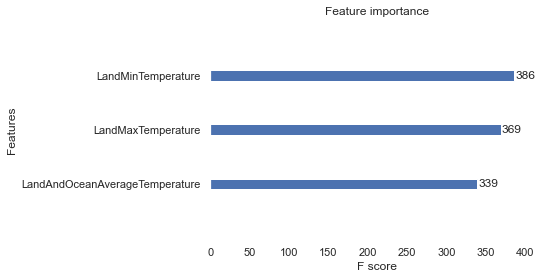

```python
#Ranking the features'importance
xgboost.plot_importance(model_fit)
```

```python
#Plotting of the tree that would predict with the highest accuracy
#The most discriminatory variable, LandMinTemperature is naturally at the top of the tree
xgboost.to_graphviz(model_fit,size="5")
```

[figure not shown]

### Adding New variables and decreasing of the MED

```python
# Adding the CO2 level as a a feature
CO2=pd.read_csv("co2-mm-mlo.csv",sep=",")
CO2
```

|  | Date | Decimal Date | Average | Interpolated | Trend | Number of Days |
| --- | --- | --- | --- | --- | --- | --- |
| 0 | 1958-03 | 1958.208 | 315.71 | 315.71 | 314.62 | -1 |
| 1 | 1958-04 | 1958.292 | 317.45 | 317.45 | 315.29 | -1 |
| 2 | 1958-05 | 1958.375 | 317.50 | 317.50 | 314.71 | -1 |
| 3 | 1958-06 | 1958.458 | -99.99 | 317.10 | 314.85 | -1 |
| 4 | 1958-07 | 1958.542 | 315.86 | 315.86 | 314.98 | -1 |
| ... | ... | ... | ... | ... | ... | ... |
| 699 | 2016-06 | 2016.458 | 406.81 | 406.81 | 404.47 | 26 |
| 700 | 2016-07 | 2016.542 | 404.39 | 404.39 | 404.00 | 28 |
| 701 | 2016-08 | 2016.625 | 402.25 | 402.25 | 404.09 | 23 |
| 702 | 2016-09 | 2016.708 | 401.03 | 401.03 | 404.46 | 24 |
| 703 | 2016-10 | 2016.792 | 401.57 | 401.57 | 404.93 | 29 |

704 rows × 6 columns

```python
# We drop the year 2016 since we don't have the temperatures of 2016
CO2 = CO2.drop(CO2.index[-10:])
CO2["Date"]=CO2["Date"]+"-01"
CO2["Date"]=pd.to_datetime(CO2["Date"])
CO2=CO2.drop(["Decimal Date","Interpolated","Trend","Number of Days"],axis=1)

# We merge the temperatures data with the CO2 data and we keep
#only the months where we have the average CO2 levels
temperatures=pd.merge(left=global_temperatures,right=CO2, left_on='dt', right_on='Date', how='outer')
temp=pd.DataFrame.copy(temperatures[temperatures['dt'].map(lambda x: x.year)<1980])
temp=temp.dropna()
temp.head(5)
```

|  | dt | LandAverageTemperature | LandMaxTemperature | LandMinTemperature | LandAndOceanAverageTemperature | Date | Average |
| --- | --- | --- | --- | --- | --- | --- | --- |
| 1298 | 1958-03-01 | 5.453 | 11.321 | -0.549 | 14.547 | 1958-03-01 | 315.71 |
| 1299 | 1958-04-01 | 8.520 | 14.392 | 2.570 | 15.359 | 1958-04-01 | 317.45 |
| 1300 | 1958-05-01 | 11.519 | 17.355 | 5.625 | 16.180 | 1958-05-01 | 317.50 |
| 1301 | 1958-06-01 | 13.187 | 19.028 | 7.427 | 16.619 | 1958-06-01 | -99.99 |
| 1302 | 1958-07-01 | 14.438 | 20.121 | 8.839 | 17.039 | 1958-07-01 | 315.86 |

### Predictive Data Modelling

### Random Forest

```python
#Sets

# Train
train_df_copy=pd.DataFrame.copy(temp)
train_df=pd.DataFrame.copy(train_df_copy)
train_df.drop(train_df.index[:1], inplace=True)
train_df_copy.drop(train_df.index[-1], inplace=True)

X_train = train_df.drop(["LandAverageTemperature","dt","Date"], axis = 1)
y_train = train_df['LandAverageTemperature']

# Test
test_df_copy=pd.DataFrame.copy(temperatures[temperatures['dt'].map(lambda x: x.year)>=1980])
test_df=pd.DataFrame.copy(test_df_copy)
test_df.drop(test_df.index[:1], inplace=True)
test_df_copy.drop(test_df.index[-1], inplace=True)

X_test = test_df.drop(["LandAverageTemperature","dt","Date"],axis = 1 )
y_test = test_df['LandAverageTemperature']
```

```python
#Definition of the Minimization Function

def MED_RF(n,maxi,
       X_train, y_train, X_test,y_test,
       MED_limit):

#Note that there is no learning_rate for the random forest regressor

    '''
    n         : n_estimators  -> Number of boosted trees to fit
    maxi      : max_depth     -> Maximum tree depth for base learners
    ...
    MED_limit : -> threshold for minimum MED required
    '''

    forest = RandomForestRegressor(n_estimators=n,max_depth = maxi)
    model_fit = forest.fit(X_train , y_train )
    y_predict = model_fit.predict(X_test)
    MED=abs(y_test-y_predict).mean()

    if MED<MED_limit:
        return MED, n, maxi
    else:
        return 0
```

```python
#Hyperparameters

max_depth = [8+i for i in range(7)]
n_estimators = [i+1 for i in range(100)]
MED_limit = 0.2
l=[]
```

```python
#### Minimization (Very long loop depending on parameters) ####

for n in n_estimators:
    for maxi in max_depth:
        a = MED_RF(n,maxi,X_train,y_train,X_test,y_test,MED_limit)
        if a != 0:
            l.append(a)
            l.sort()

l[:5] # 5 Best MED Results
```

```
[(0.1317968638585405, 96, 11),
 (0.13397702695735553, 34, 9),
 (0.13592621809744804, 15, 14),
 (0.1364931931177874, 22, 11),
 (0.13674895157839734, 90, 8)]
```

```python
# GridSearch (very long)

'''clf = GridSearchCV(forest,
                   {'max_depth': max_depth,
                    'n_estimators': n_estimators}, verbose=1)

clf.fit(X_train,y_train)
clf.best_score_, clf.best_params_'''

'''
output:
(0.9995155048564097, {'max_depth': 14, 'n_estimators': 36})'''
```

```
"\noutput:\n(0.9995155048564097, {'max_depth': 14, 'n_estimators': 36})"
```

### Random Forest Regressor

```python
#Random Forest (GridSearch MED Test)

# To predict each average land temperature we use the previous year's temperatures (landandocean, min , max) and the CO2 level of the current year
for j in (train_df.index):
    for column in train_df.columns[1:-2]:
        train_df.loc[j,column]=train_df_copy.loc[j-1,column]
forest = RandomForestRegressor(max_depth=10,n_estimators=462)
train_df=train_df.drop(['dt',"Date"],axis=1)
forest = forest.fit(train_df.drop(["LandAverageTemperature"],axis=1),train_df["LandAverageTemperature"])

for j in (test_df.index):
    for column in test_df.columns[1:-2]:
        test_df.loc[j,column]=test_df_copy.loc[j-1,column]
test_df=test_df.drop(['dt',"Date"],axis=1)
y_pred = forest.predict(test_df.drop(["LandAverageTemperature"],axis=1))

# Distance computing
y_test = test_df['LandAverageTemperature']
test_df['Predicted_temp']=y_pred
MED=abs(y_test-y_pred).mean()
print('Mean Euclidean Distance:', MED)
print('Mean Absolute Error:', metrics.mean_absolute_error(y_test, y_pred))
print('Mean Squared Error:', metrics.mean_squared_error(y_test, y_pred))
print('Root Mean Squared Error:', np.sqrt(metrics.mean_squared_error(y_test, y_pred)))
print('R2 Square:', metrics.r2_score(y_test, y_pred))
```

```
Mean Euclidean Distance: 0.15216682177761248
Mean Absolute Error: 0.15216682177761254
Mean Squared Error: 0.047517517651059125
Root Mean Squared Error: 0.2179851317201683
R2 Square: 0.9972203290573709
```

### XGBoost

```python
#Sets

# Train
train_df_copy_2=pd.DataFrame.copy(temperatures[temperatures['dt'].map(lambda x: x.year)<1980])
train_df_2=pd.DataFrame.copy(train_df_copy_2)
train_df_2.drop(train_df_2.index[:1], inplace=True)
train_df_copy_2.drop(train_df_2.index[-1], inplace=True)

# Test
test_df_copy_2=pd.DataFrame.copy(temperatures[temperatures['dt'].map(lambda x: x.year)>=1980])
test_df_2=pd.DataFrame.copy(test_df_copy_2)
test_df_2.drop(test_df_2.index[:1], inplace=True)
test_df_copy_2.drop(test_df_2.index[-1], inplace=True)
```

```python
#XGBoost (GridSearch MED Test)

# To predict each average land temperature we use the previous year's temperatures (landandocean, min, max) and the CO2 level of the current year

for j in (train_df_2.index):
    for column in train_df_2.columns[1:-2]:
        train_df_2.loc[j,column]=train_df_copy_2.loc[j-1,column]
xgbr = XGBRegressor()
xgbr = xgbr.fit(train_df_2.drop(["LandAverageTemperature","dt","Date"],axis=1),train_df_2["LandAverageTemperature"])


for j in (test_df_2.index):
    for column in test_df_2.columns[1:-2]:
        test_df_2.loc[j,column]=test_df_copy_2.loc[j-1,column]
y_test = test_df_2["LandAverageTemperature"]
y_pred = xgbr.predict(test_df_2.drop(["LandAverageTemperature","dt","Date"],axis=1))

# Distance computing
test_df_2['Predicted_temp']=y_pred

MED=abs(y_test-y_pred).mean()
print('Mean Euclidean Distance:', MED)
print('Mean Absolute Error:', metrics.mean_absolute_error(y_test, y_pred))
print('Mean Squared Error:', metrics.mean_squared_error(y_test, y_pred))
print('Root Mean Squared Error:', np.sqrt(metrics.mean_squared_error(y_test, y_pred)))
print('R2 Square:', metrics.r2_score(y_test, y_pred))
```

```
Mean Euclidean Distance: 0.29600491955661995
Mean Absolute Error: 0.2960049195566199
Mean Squared Error: 0.15827613109816896
Root Mean Squared Error: 0.39783932824466833
R2 Square: 0.9907411922113417
```

```python
#Hyperparameters

max_depth = [2+i for i in range(4)]
learning_rate = [0.01+0.01*i for i in range(5)]
n_estimators = [450+i*10 for i in range(10)]
MED_limit = 2
l=[]
```

```python
#### Minimization (Very long loop depending on parameters) ####

for n in n_estimators:
    for learn in learning_rate:
        for maxi in max_depth:
            a = MED_XGB(n,maxi,learn,X_train,y_train,X_test,y_test,MED_limit)
            if a != 0:
                l.append(a)
                l.sort()

l[:5] # 5 Best MED Results
```

```
[(1.538265638484202, 540, 0.04, 4),
 (1.5388368839210809, 530, 0.04, 4),
 (1.538874825665679, 490, 0.02, 4),
 (1.5389709846381516, 500, 0.02, 4),
 (1.5391198457863928, 510, 0.02, 4)]
```

```python
# GridSearch (very long)

'''clf = GridSearchCV(xgbr,
                   {'max_depth': max_depth,
                    'n_estimators': n_estimators,
                   'learning_rate': learning_rate}, verbose=1)

clf.fit(X_train,y_train)
clf.best_score_, clf.best_params_'''
'''
Output:
(0.9333152336083268,
 {'learning_rate': 0.01, 'max_depth': 3, 'n_estimators': 520})'''
```

```
"\nOutput:\n(0.9333152336083268,\n {'learning_rate': 0.01, 'max_depth': 3, 'n_estimators': 520})"
```

## Clustering

### Preparing the DataFrame

```python
country_temps = pd.read_csv("GlobalLandTemperaturesByCountry.csv", sep=',')
country_temps.head(5)
```

|  | dt | AverageTemperature | AverageTemperatureUncertainty | Country |
| --- | --- | --- | --- | --- |
| 0 | 1743-11-01 | 4.384 | 2.294 | Åland |
| 1 | 1743-12-01 | NaN | NaN | Åland |
| 2 | 1744-01-01 | NaN | NaN | Åland |
| 3 | 1744-02-01 | NaN | NaN | Åland |
| 4 | 1744-03-01 | NaN | NaN | Åland |

```python
#Drop Uncertainty for the clustering

country_temps = country_temps.drop("AverageTemperatureUncertainty", axis = 1)

# Delete all empty lines, change time, and put time as Index

country_temps['dt'] = pd.to_datetime(country_temps['dt'])

country_temps.tail()

#Setting the Countries as Index, time as Columns and Average Temperature as the main Data
pivot = country_temps.pivot("Country","dt","AverageTemperature")

pivot = pivot.drop(pivot.columns[[i for i in range(1274)]+[3238]], axis = 1)

"""
    Data before 1850 is deleted because

    *30%  of Database is NaN if dt starts at 1773
    *18%  of Database is NaN if dt starts at 1800
    *5.2% of Database is NaN if dt starts at 1850

    Numbers obtained doing :
        -> np.count_nonzero(~np.isnan(pivot))

    Plus, the last month (9/2013) doesn't have any data

"""
#Getting rid of all countries with no data
pivot = pivot.dropna(how='all') #aucune donnée pour le pays

#Only one country eliminated
pivot.head(5)
```

| dt Country | 1850-01-01 | 1850-02-01 | 1850-03-01 | 1850-04-01 | 1850-05-01 | 1850-06-01 | 1850-07-01 | 1850-08-01 | 1850-09-01 | 1850-10-01 | ... | 2012-11-01 | 2012-12-01 | 2013-01-01 | 2013-02-01 | 2013-03-01 | 2013-04-01 | 2013-05-01 | 2013-06-01 | 2013-07-01 | 2013-08-01 |
| --- | --- | --- | --- | --- | --- | --- | --- | --- | --- | --- | --- | --- | --- | --- | --- | --- | --- | --- | --- | --- | --- |
| Afghanistan | -1.288 | 3.143 | 8.583 | 13.456 | 18.717 | 23.859 | 27.194 | 24.843 | 19.792 | 12.560 | ... | 8.700 | 2.907 | 2.241 | 4.253 | 8.460 | 14.845 | 21.355 | 26.879 | 28.205 | 26.031 |
| Africa | 19.764 | 22.393 | 23.672 | 24.197 | 24.302 | 24.980 | 25.089 | 25.254 | 24.919 | 23.831 | ... | 24.607 | 21.983 | 22.138 | 23.533 | 25.717 | 25.520 | 26.671 | 26.324 | 25.856 | 25.911 |
| Albania | -0.160 | 4.270 | 4.868 | 10.700 | 14.758 | 20.138 | 21.840 | 22.736 | 16.512 | 12.763 | ... | 11.269 | 3.820 | 4.412 | 5.769 | 8.423 | 13.538 | 18.355 | 21.070 | 23.591 | 24.793 |
| Algeria | 10.604 | 14.819 | 18.362 | 22.717 | 26.391 | 31.143 | 33.656 | 33.000 | 28.880 | 22.708 | ... | 20.031 | 13.638 | 12.781 | 14.211 | 21.027 | 24.242 | 28.482 | 32.288 | 34.707 | 33.234 |
| American Samoa | NaN | NaN | NaN | NaN | NaN | NaN | NaN | NaN | NaN | NaN | ... | 27.963 | 27.316 | 27.241 | 27.793 | 27.683 | 27.824 | 28.045 | 27.650 | 26.902 | 27.000 |

5 rows × 1964 columns

### Country Clustering

##### Adding Median to missing values

```python
from sklearn.impute import SimpleImputer

imp = SimpleImputer(strategy="median")
#Imputer changes type of DataFrame.

trans_pivot = imp.fit_transform(pivot)
nonan_pivot = pd.DataFrame(trans_pivot)

nonan_pivot.columns = pivot.columns
nonan_pivot.index = pivot.index

nonan_pivot.tail()

print(np.count_nonzero(~np.isnan(nonan_pivot)))

#No missing data, and let's now call the DataFrame : clusterdf

clusterdf = nonan_pivot
clusterdf.head(5)
```

```
475288
```

| dt Country | 1850-01-01 | 1850-02-01 | 1850-03-01 | 1850-04-01 | 1850-05-01 | 1850-06-01 | 1850-07-01 | 1850-08-01 | 1850-09-01 | 1850-10-01 | ... | 2012-11-01 | 2012-12-01 | 2013-01-01 | 2013-02-01 | 2013-03-01 | 2013-04-01 | 2013-05-01 | 2013-06-01 | 2013-07-01 | 2013-08-01 |
| --- | --- | --- | --- | --- | --- | --- | --- | --- | --- | --- | --- | --- | --- | --- | --- | --- | --- | --- | --- | --- | --- |
| Afghanistan | -1.288 | 3.143 | 8.583 | 13.456 | 18.717 | 23.859 | 27.194 | 24.843 | 19.792 | 12.560 | ... | 8.700 | 2.907 | 2.241 | 4.253 | 8.460 | 14.845 | 21.355 | 26.879 | 28.205 | 26.031 |
| Africa | 19.764 | 22.393 | 23.672 | 24.197 | 24.302 | 24.980 | 25.089 | 25.254 | 24.919 | 23.831 | ... | 24.607 | 21.983 | 22.138 | 23.533 | 25.717 | 25.520 | 26.671 | 26.324 | 25.856 | 25.911 |
| Albania | -0.160 | 4.270 | 4.868 | 10.700 | 14.758 | 20.138 | 21.840 | 22.736 | 16.512 | 12.763 | ... | 11.269 | 3.820 | 4.412 | 5.769 | 8.423 | 13.538 | 18.355 | 21.070 | 23.591 | 24.793 |
| Algeria | 10.604 | 14.819 | 18.362 | 22.717 | 26.391 | 31.143 | 33.656 | 33.000 | 28.880 | 22.708 | ... | 20.031 | 13.638 | 12.781 | 14.211 | 21.027 | 24.242 | 28.482 | 32.288 | 34.707 | 33.234 |
| American Samoa | 13.960 | 15.370 | 18.443 | 20.359 | 21.059 | 23.902 | 24.512 | 24.570 | 23.448 | 22.030 | ... | 27.963 | 27.316 | 27.241 | 27.793 | 27.683 | 27.824 | 28.045 | 27.650 | 26.902 | 27.000 |

5 rows × 1964 columns

#### Clustering Code

```python
def Clustering(df,x,y,orientation,size):

    """

    df          : DataFrame
    x,y         : plt dimensions
    orientation : top, bottom, right or left
    size        : leaf_font_size

    """
    from sklearn.cluster import AgglomerativeClustering
    from scipy.cluster.hierarchy import dendrogram
    import matplotlib.pyplot as plt
    plt.style.use('ggplot')

    ward = AgglomerativeClustering(linkage='ward', compute_full_tree=True).fit(df)
    dendro = [ ]
    for a,b in ward.children_:
        dendro.append([a,b,float(len(dendro)+1),len(dendro)+1])

    fig = plt.figure( figsize=(x,y) )
    ax = fig.add_subplot(1,1,1)
    r = dendrogram(
        dendro,
        color_threshold=None,
        labels=df.index,
        distance_sort = True,
        show_leaf_counts=False,
        leaf_font_size = size,
        ax=ax,
        orientation = str(orientation)
    )

def Clustering_truncated(df,x,y,orientation,p,size):

    """

    df          : DataFrame
    x,y         : plt dimensions
    orientation : top, bottom, right or left
    p           : Only the last p merged clusters are shown
    size        : leaf_font_size

    """
    from sklearn.cluster import AgglomerativeClustering
    from scipy.cluster.hierarchy import dendrogram
    import matplotlib.pyplot as plt
    plt.style.use('ggplot')

    ward = AgglomerativeClustering(linkage='ward', compute_full_tree=True).fit(df)
    dendro = [ ]
    for a,b in ward.children_:
        dendro.append([a,b,float(len(dendro)+1),len(dendro)+1])

    fig = plt.figure( figsize=(x,y) )
    ax = fig.add_subplot(1,1,1)
    r = dendrogram(
        dendro,
        color_threshold=None,
        labels=df.index,
        show_leaf_counts=False,
        truncate_mode = 'lastp',  # show only the last p merged clusters
        p = p,  # show only the last p merged clusters
        leaf_font_size = size,
        show_contracted = True,  # to get a distribution impression in truncated branches
        ax=ax,
        orientation = str(orientation)

    )
    return r["ivl"]
```

#### $1^{st}$ Clustering : All Countries

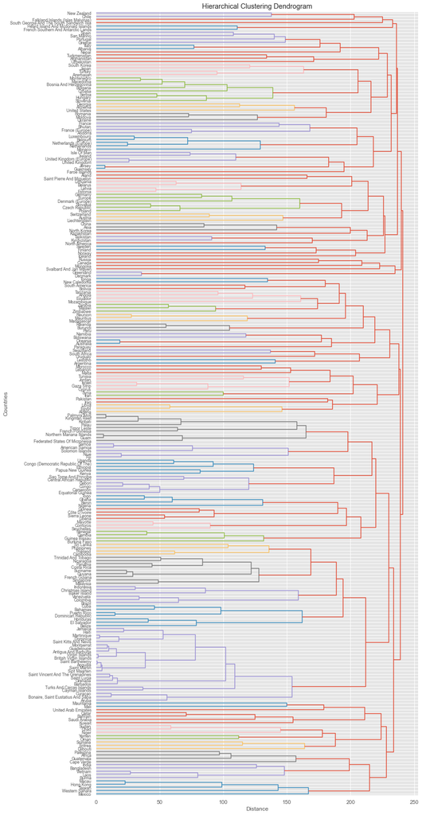

```python
Clustering(clusterdf,12,30,"right",8.5)
plt.title('Hierarchical Clustering Dendrogram')
plt.ylabel('Countries')
plt.xlabel('Distance')
```

#### 2nd Clustering

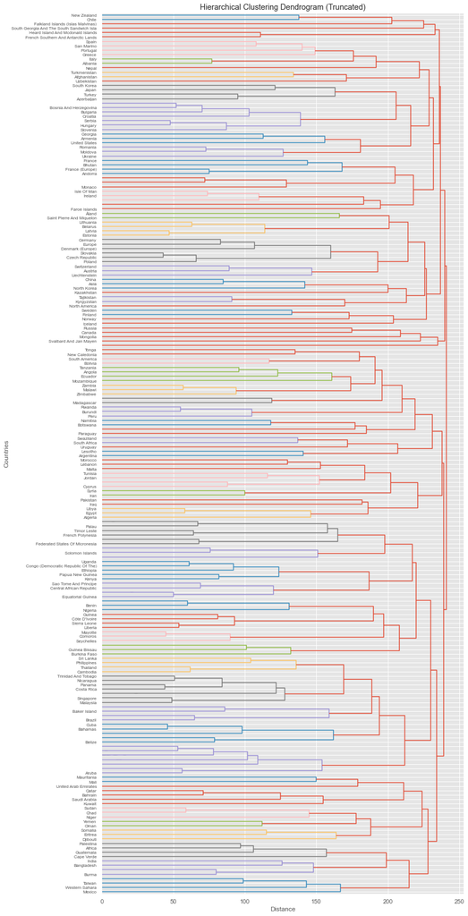

```python
Cluster_70 = Clustering_truncated(clusterdf,12,30,"right",200,8)
plt.title('Hierarchical Clustering Dendrogram (Truncated)')
plt.xlabel('Distance')
plt.ylabel('Countries')
```

```python
Cluster_70[:15]
```

```
['Mexico',
 'Western Sahara',
 'Taiwan',
 '',
 'Burma',
 '',
 'Bangladesh',
 'India',
 'Cape Verde',
 'Guatemala',
 'Africa',
 'Palestina',
 'Djibouti',
 'Eritrea',
 'Somalia']
```

```python
def delete_symbol(l,sym):
    for i in range(l.count(sym)):
        l.remove(sym)
    return l, len(l)
```

```python
cntry_to_keep = delete_symbol(Cluster_70,'')
```

```python
clusterdf_new = clusterdf.drop(cntry_to_keep[0], axis = 0)
clusterdf_new.head()
```

| dt Country | 1850-01-01 | 1850-02-01 | 1850-03-01 | 1850-04-01 | 1850-05-01 | 1850-06-01 | 1850-07-01 | 1850-08-01 | 1850-09-01 | 1850-10-01 | ... | 2012-11-01 | 2012-12-01 | 2013-01-01 | 2013-02-01 | 2013-03-01 | 2013-04-01 | 2013-05-01 | 2013-06-01 | 2013-07-01 | 2013-08-01 |
| --- | --- | --- | --- | --- | --- | --- | --- | --- | --- | --- | --- | --- | --- | --- | --- | --- | --- | --- | --- | --- | --- |
| American Samoa | 13.960 | 15.370 | 18.443 | 20.359 | 21.059 | 23.902 | 24.512 | 24.570 | 23.448 | 22.030 | ... | 27.963 | 27.316 | 27.241 | 27.793 | 27.683 | 27.824 | 28.045 | 27.650 | 26.902 | 27.000 |
| Anguilla | 24.075 | 24.985 | 25.064 | 24.859 | 25.734 | 27.073 | 27.922 | 27.949 | 27.696 | 26.701 | ... | 28.203 | 26.476 | 25.919 | 25.899 | 26.187 | 26.679 | 27.667 | 28.414 | 28.904 | 29.235 |
| Antigua And Barbuda | 23.930 | 24.845 | 24.984 | 24.879 | 25.711 | 26.988 | 27.714 | 27.672 | 27.346 | 26.351 | ... | 27.890 | 26.329 | 25.787 | 25.802 | 26.089 | 26.601 | 27.706 | 28.322 | 28.712 | 28.978 |
| Australia | 13.960 | 15.370 | 18.443 | 20.359 | 21.059 | 23.902 | 24.512 | 24.570 | 23.448 | 22.030 | ... | 26.935 | 28.417 | 29.861 | 28.311 | 26.590 | 23.305 | 19.377 | 16.018 | 15.933 | 17.748 |
| Barbados | 24.249 | 25.140 | 25.271 | 25.304 | 25.918 | 27.006 | 27.312 | 27.109 | 26.968 | 26.298 | ... | 27.922 | 26.744 | 26.088 | 26.182 | 26.504 | 26.806 | 27.849 | 28.020 | 28.284 | 28.276 |

5 rows × 1964 columns

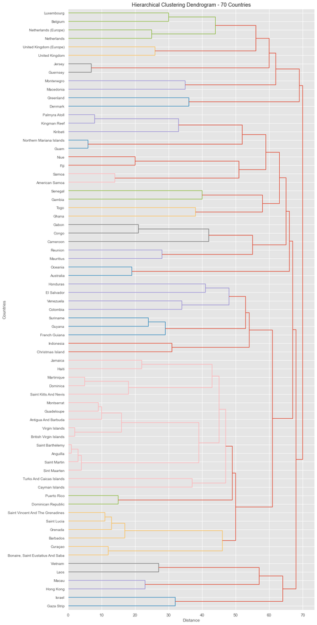

```python
Clustering(clusterdf_new,12,30,"right",10)
plt.title('Hierarchical Clustering Dendrogram - 70 Countries')
plt.xlabel('Distance')
plt.ylabel('Countries')
```

## Data Visualization

### Conclusion on multiple cities

```python
def city_analysis(df, city):
    #Building of a new Dataframe adapted to the map
    print("\n\n\nCity = ", city, "\n\n\n")
    import math
    from collections import OrderedDict
    import pandas as pd
    import numpy as np
    from bokeh.io import output_notebook, show
    from bokeh.plotting import (ColumnDataSource, figure)
    from bokeh.models import HoverTool
    df=df[df.City == city]
    df['dt2'] = df['dt'].apply(lambda x: x[:4])
    df['dt2'] = pd.to_numeric(df['dt2'])
    df.drop(df[df.dt2 < 1800].index, inplace=True)
    df=df.drop(df.columns[2:6], axis=1)
    df=df.dropna()
    df_city = copy.deepcopy(df)

    date=df_city['dt'].apply(lambda x: x[:4])
    years = np.unique(date)
    mean_temps_Paris=[]

    for y in years:

        mean_temps_Paris.append(df_city[y==date]['AverageTemperature'].mean())
    len_df = len(df_city) - 1
    jan=[]
    for i in range(0,len_df,12):
            jan.append(df_city.iloc[i]['AverageTemperature'])
    feb=[]
    for i in range(1,len_df,12):
            feb.append(df_city.iloc[i]['AverageTemperature'])
    mar=[]
    for i in range(2,len_df,12):
            mar.append(df_city.iloc[i]['AverageTemperature'])
    apr=[]
    for i in range(3,len_df,12):
            apr.append(df_city.iloc[i]['AverageTemperature'])
    may=[]
    for i in range(4,len_df,12):
            may.append(df_city.iloc[i]['AverageTemperature'])
    jun=[]
    for i in range(5,len_df,12):
            jun.append(df_city.iloc[i]['AverageTemperature'])
    jul=[]
    for i in range(6,len_df,12):
            jul.append(df_city.iloc[i]['AverageTemperature'])
    aug=[]
    for i in range(7,len_df,12):
            aug.append(df_city.iloc[i]['AverageTemperature'])
    sep=[]
    for i in range(8,len_df,12):
            sep.append(df_city.iloc[i]['AverageTemperature'])
    octb=[]
    for i in range(9,len_df,12):
            octb.append(df_city.iloc[i]['AverageTemperature'])
    nov=[]
    for i in range(10,len_df,12):
            nov.append(df_city.iloc[i]['AverageTemperature'])
    dec=[]
    for i in range(11,len_df,12):
            dec.append(df_city.iloc[i]['AverageTemperature'])

    #New Dataframe

    df_city=pd.DataFrame({'Annual':pd.Series(mean_temps_Paris),'Year':years,'Jan':pd.Series(jan),
                        'Feb':pd.Series(feb),'Mar':pd.Series(mar),'Apr':pd.Series(apr),'May':pd.Series(may),
                        'Jun':pd.Series(jun),'Jul':pd.Series(jul),'Aug':pd.Series(aug),'Sep':pd.Series(sep),'Oct':pd.Series(octb),
                        'Nov':pd.Series(nov),'Dec':pd.Series(dec)})

    df_city=df_city[['Year','Jan','Feb','Mar','Apr','May','Jun','Jul','Aug','Sep','Oct','Nov','Dec','Annual']]
    df_city=df_city.dropna()
    print(df_city)
    min_temp = df_city[['Jan','Feb','Mar','Apr','May','Jun',
                        'Jul','Aug','Sep','Oct','Nov','Dec']].stack().min()
    max_temp = df_city[['Jan','Feb','Mar','Apr','May','Jun',
                        'Jul','Aug','Sep','Oct','Nov','Dec']].stack().max()
    print("min_temp = ", min_temp, "\nmax_temp = ", max_temp)

    #Interactive map with monthly average temperatures in Paris since 1900

    output_notebook()
    df_city.reset_index(inplace=True)
    # Read in the data with pandas. Convert the year column to string
    df_city['Year'] = [str(x) for x in df_city['Year']]
    years = list(df_city['Year'])
    months = ["Jan","Feb","Mar","Apr","May","Jun","Jul","Aug","Sep","Oct","Nov","Dec"]
    df_city = df_city.set_index('Year')
    # this is the colormap from the original plot

    colors = ["#75968f", "#75968f", "#a5bab7", "#c9d9d3", "#e2e2e2", "#dfccce",
            "#ddb7b1", "#cc7878", "#933b41", "#550b1d","#75968f","#75968f"]

    # Set up the data for plotting. We will need to have values for every
    # pair of year/month names. Map the Temperature to a color.
    def mapping_to_colors2(x):
        indx = abs(int(math.ceil((max_temp - min_temp)/8)))
        c = 0
        for i in range(int(min_temp), int(max_temp), int(indx)):
            c = c + 1
            if(x<i):
                return c
        return 8
    def mapping_to_colors(x):
        if x<=0:
            return 1
        elif x>=0 and x<4:
            return 2
        elif x>=4 and x<8:
            return 3
        elif x>=8 and x<12:
            return 4
        elif x>=12 and x<14:
            return 5
        elif x>=14 and x<19:
            return 6
        elif x>=19 and x<22:
            return 7
        else:
            return 8

    month = []
    year = []
    color = []
    Temperature = []
    for y in years:
        for m in months:
            month.append(m)
            year.append(y)
            Monthly_Temperature = df_city[m][y]
            Temperature.append(Monthly_Temperature)
            color.append(colors[mapping_to_colors2(Monthly_Temperature)])

    source = ColumnDataSource(
        data=dict(month=month, year=year, color=color, Temperature=Temperature)
    )

    TOOLS = "hover,save,pan,box_zoom,wheel_zoom"

    #Display parameters
    p = figure(title=city + " Temperature (1900 - 2012)",
        x_range=years, y_range=list(reversed(months)),
        x_axis_location="above", plot_width=3000, plot_height=500,
        toolbar_location="below", tools=TOOLS,)

    p.rect("year", "month", 1, 1, source=source,
        color="color", line_color=None)

    p.grid.grid_line_color = None
    p.axis.axis_line_color = None
    p.axis.major_tick_line_color = None
    p.axis.major_label_text_font_size = "5pt"
    p.axis.major_label_standoff = 0
    p.xaxis.major_label_orientation = np.pi/3

    #Hovers parameters
    hover = p.select(dict(type=HoverTool))
    hover.tooltips = OrderedDict([
        ('date', '@month @year'),
        ('Temperature', '@Temperature'),])

    show(p)
```

```python
df=pd.read_csv('GlobalLandTemperaturesByMajorCity.csv')
print(df['City'].unique())
print("\n\n\n")
```

```
['Abidjan' 'Addis Abeba' 'Ahmadabad' 'Aleppo' 'Alexandria' 'Ankara'
 'Baghdad' 'Bangalore' 'Bangkok' 'Belo Horizonte' 'Berlin' 'Bogotá'
 'Bombay' 'Brasília' 'Cairo' 'Calcutta' 'Cali' 'Cape Town' 'Casablanca'
 'Changchun' 'Chengdu' 'Chicago' 'Chongqing' 'Dakar' 'Dalian'
 'Dar Es Salaam' 'Delhi' 'Dhaka' 'Durban' 'Faisalabad' 'Fortaleza' 'Gizeh'
 'Guangzhou' 'Harare' 'Harbin' 'Ho Chi Minh City' 'Hyderabad' 'Ibadan'
 'Istanbul' 'Izmir' 'Jaipur' 'Jakarta' 'Jiddah' 'Jinan' 'Kabul' 'Kano'
 'Kanpur' 'Karachi' 'Kiev' 'Kinshasa' 'Lagos' 'Lahore' 'Lakhnau' 'Lima'
 'London' 'Los Angeles' 'Luanda' 'Madras' 'Madrid' 'Manila' 'Mashhad'
 'Melbourne' 'Mexico' 'Mogadishu' 'Montreal' 'Moscow' 'Nagoya' 'Nagpur'
 'Nairobi' 'Nanjing' 'New Delhi' 'New York' 'Paris' 'Peking' 'Pune'
 'Rangoon' 'Rio De Janeiro' 'Riyadh' 'Rome' 'São Paulo' 'Saint Petersburg'
 'Salvador' 'Santiago' 'Santo Domingo' 'Seoul' 'Shanghai' 'Shenyang'
 'Singapore' 'Surabaya' 'Surat' 'Sydney' 'Taipei' 'Taiyuan' 'Tangshan'
 'Tianjin' 'Tokyo' 'Toronto' 'Umm Durman' 'Wuhan' 'Xian']
```

```python
city = 'Hyderabad'
city_analysis(df, city)
```

```
City =  Hyderabad



     Year     Jan     Feb     Mar     Apr     May     Jun     Jul     Aug  \
0    1800  22.979  25.527  28.376  32.456  32.221  30.372  26.605  26.536
1    1801  23.231  24.779  30.266  29.925  27.233  27.055  26.497  25.537
2    1802  30.112  31.989  32.084  31.613  28.202  27.003  28.193  26.075
3    1803  28.727  32.021  32.715  30.881  28.074  28.169  27.816  25.927
4    1804  28.662  32.941  33.494  31.384  29.083  27.167  27.564  25.834
..    ...     ...     ...     ...     ...     ...     ...     ...     ...
200  2007  33.765  30.131  28.513  26.843  26.898  26.534  24.781  23.396
201  2008  33.516  31.014  28.266  28.008  27.699  26.658  24.923  23.173
202  2009  33.482  30.639  26.996  27.159  26.905  26.418  25.167  22.234
203  2010  33.142  30.149  27.735  27.068  27.610  27.192  24.861  23.613
204  2011  34.331  31.775  27.925  27.504  27.679  26.236  24.641  24.006

        Sep     Oct     Nov     Dec     Annual
0    26.096  25.808  23.707  21.839  26.876833
1    23.309  22.714  23.516  25.738  26.054600
2    23.248  21.544  22.009  24.538  27.443083
3    23.702  22.096  23.833  25.640  27.222917
4    24.547  21.694  22.955  25.079  27.653583
..      ...     ...     ...     ...        ...
200  23.848  27.376  29.345  32.492  27.545333
201  23.185  26.463  30.424  33.249  27.446667
202  22.687  25.243  29.067  30.539  28.026500
203  23.829  26.526  29.927  31.844  27.693417
204  24.670  26.226  29.598  32.245  27.408833

[205 rows x 14 columns]
min_temp =  19.576
max_temp =  34.701
```

[interactive chart not shown]

```python
city = 'New Delhi'
city_analysis(df, city)
```

```
City =  New Delhi



     Year     Jan     Feb     Mar     Apr     May     Jun     Jul     Aug  \
0    1800  14.525  17.781  22.055  29.968  32.960  33.978  30.926  29.686
1    1801  14.932  16.778  24.344  33.279  31.788  29.407  28.708  25.967
2    1802  24.033  29.228  32.784  35.057  32.112  30.222  29.480  26.544
3    1803  22.459  29.908  34.062  34.291  32.261  31.455  29.740  26.245
4    1804  22.327  30.744  34.307  34.491  32.972  30.453  29.538  26.056
..    ...     ...     ...     ...     ...     ...     ...     ...     ...
190  2007  21.927  15.925  14.534  16.809  25.979  29.609  32.313  31.151
191  2008  21.769  17.845  16.096  19.479  24.655  30.182  34.067  35.543
192  2009  21.214  16.871  14.014  19.178  26.953  32.809  35.610  35.165
193  2010  21.757  15.393  13.376  18.136  23.864  28.956  34.298  32.967
194  2011  22.484  16.203  13.701  17.088  23.686  29.341  34.448  36.339

        Sep     Oct     Nov     Dec     Annual
0    28.000  26.310  20.450  15.849  25.207333
1    20.463  16.495  15.508  17.593  24.216100
2    20.134  14.843  12.767  15.983  25.628167
3    20.645  14.733  14.616  16.678  25.379083
4    21.536  14.431  14.681  16.873  25.679083
..      ...     ...     ...     ...        ...
190  30.918  29.868  29.513  27.792  26.145667
191  32.271  31.519  30.154  26.600  25.675000
192  31.465  30.031  28.612  27.256  26.554250
193  30.947  30.075  29.399  26.849  26.520250
194  32.448  29.833  29.759  26.354  25.629500

[195 rows x 14 columns]
min_temp =  11.378
max_temp =  36.33900000000001
```

[interactive chart not shown]

```python
city = 'Bombay'
city_analysis(df, city)
```

```
City =  Bombay



     Year     Jan     Feb     Mar     Apr     May     Jun     Jul     Aug  \
0    1800  24.394  24.477  25.033  28.385  28.427  28.650  26.586  26.526
1    1801  24.724  23.601  27.124  28.076  27.332  26.643  26.777  27.569
2    1802  26.891  27.781  28.269  29.809  27.975  27.028  28.007  28.127
3    1803  25.411  28.140  29.227  29.060  27.987  28.228  27.951  27.903
4    1804  25.312  29.017  29.737  29.411  28.846  27.226  27.725  27.761
..    ...     ...     ...     ...     ...     ...     ...     ...     ...
200  2007  29.540  28.223  27.554  26.831  27.193  28.655  28.512  27.435
201  2008  29.735  29.548  27.385  27.852  28.173  28.396  28.324  27.043
202  2009  30.682  28.881  27.364  27.279  27.587  28.774  28.883  25.460
203  2010  29.546  28.394  27.133  27.122  27.390  28.864  29.040  26.850
204  2011  29.235  28.847  27.941  27.405  27.491  28.689  27.540  26.828

        Sep     Oct     Nov     Dec     Annual
0    26.221  27.877  27.470  25.849  26.657917
1    27.280  26.609  25.155  24.487  26.573500
2    27.083  25.195  23.025  23.080  27.150583
3    27.566  25.413  24.862  23.976  26.915917
4    28.435  25.061  24.461  23.797  27.280750
..      ...     ...     ...     ...        ...
200  25.783  25.766  27.193  28.936  27.634667
201  26.120  25.615  27.362  29.178  27.177750
202  24.543  25.031  26.990  27.716  27.844500
203  23.844  24.693  25.574  28.223  27.765417
204  24.187  25.005  26.301  27.335  27.384917

[205 rows x 14 columns]
min_temp =  21.01
max_temp =  30.682
```

[interactive chart not shown]

```python
city = 'London'
city_analysis(df, city)
```

```
City =  London



     Year    Jan    Feb    Mar     Apr     May     Jun     Jul     Aug  \
0    1800  2.624  1.865  3.617   9.801  13.087  13.207  17.236  17.728
1    1801  4.326  3.735  6.898   8.096  12.267  14.632  16.089  17.456
2    1802  0.956  3.852  5.588   8.953  11.122  14.608  14.800  18.014
3    1803  0.454  2.082  5.585   9.182  10.266  13.944  17.900  16.591
4    1804  5.737  2.690  4.552   6.462  13.529  16.039  15.959  15.741
..    ...    ...    ...    ...     ...     ...     ...     ...     ...
208  2008  6.721  5.386  6.358   8.275  13.860  15.243  17.464  17.070
209  2009  2.769  4.088  7.019  10.268  13.115  15.585  17.114  17.945
210  2010  1.381  2.812  6.422   9.292  11.328  16.130  18.805  16.242
211  2011  4.100  6.488  6.862  12.071  13.290  15.178  15.992  16.484
212  2012  5.313  3.723  7.964   7.496  12.341  13.477  16.487  17.697

        Sep     Oct    Nov    Dec     Annual
0    14.427   9.107  5.842  3.266   9.317250
1    14.890  10.417  4.981  2.402   9.682417
2    14.396  10.085  5.596  3.744   9.309500
3    11.473   8.933  5.096  4.002   8.792333
4    14.842  10.074  5.707  1.088   9.368333
..      ...     ...    ...    ...        ...
208  13.759   9.634  7.156  3.605  10.377583
209  14.926  11.392  8.791  3.270  10.523500
210  14.188  10.466  5.464 -0.024   9.375500
211  15.767  12.774  9.609  5.708  11.193583
212  13.901   9.895  6.828  4.849   9.997583

[213 rows x 14 columns]
min_temp =  -2.781
max_temp =  20.743
```

[interactive chart not shown]

```python
city = 'Tokyo'
city_analysis(df, city)
```

```
City =  Tokyo



     Year     Jan     Feb     Mar     Apr     May     Jun     Jul     Aug  \
0    1845   2.377   1.312   5.276  10.387  14.923  19.497  23.979  24.109
1    1846   1.474   1.824   5.852  10.111  14.366  19.724  23.845  24.931
2    1847   1.730   1.895   4.195  10.555  14.876  19.081  23.574  24.664
3    1848  -0.108   2.401   5.021  10.498  15.242  19.392  23.898  24.014
4    1849   1.647   2.797   6.124   9.667  14.536  19.233  23.032  24.299
..    ...     ...     ...     ...     ...     ...     ...     ...     ...
163  2008  16.164  19.392  24.848  24.506  21.323  15.746   9.247   5.430
164  2009  17.633  20.318  23.875  24.193  20.272  15.161   9.835   4.895
165  2010  16.337  21.521  25.558  27.295  22.414  15.881   9.515   5.719
166  2011  16.147  21.085  25.288  25.202  22.199  15.488  10.803   3.250
167  2012  16.670  19.359  24.444  26.681  23.275  15.722   8.718   2.961

        Sep     Oct    Nov     Dec     Annual
0    19.507  12.911  7.231   1.869  11.948167
1    20.703  13.883  7.745   4.396  12.404500
2    20.113  13.648  9.117   3.042  12.207500
3    19.749  14.187  7.494   3.850  12.136500
4    20.301  13.785  7.824   2.414  12.138250
..      ...     ...    ...     ...        ...
163   2.864   4.269  6.678  12.560  13.310667
164   2.608   3.306  6.103   9.589  13.546083
165   0.817   3.734  4.674  11.175  13.820500
166   0.715   1.842  5.617  11.355  13.321833
167   1.288   2.046  7.955  11.310  13.113250

[168 rows x 14 columns]
min_temp =  -1.5799999999999998
max_temp =  27.295
```

[interactive chart not shown]

```python
city = 'Calcutta'
city_analysis(df, city)
```

```
City =  Calcutta



     Year     Jan     Feb     Mar     Apr     May     Jun     Jul     Aug  \
0    1800  18.694  22.134  25.840  30.722  30.266  30.189  28.565  28.806
1    1801  19.073  21.177  28.057  29.535  29.385  28.670  28.414  26.854
2    1802  27.774  30.032  30.096  31.297  29.825  29.329  29.350  27.424
3    1803  26.234  30.596  31.259  30.537  29.924  30.551  29.496  27.152
4    1804  26.114  31.447  31.599  30.791  30.689  29.549  29.286  26.980
..    ...     ...     ...     ...     ...     ...     ...     ...     ...
202  2007  31.134  29.111  28.852  29.284  29.087  27.422  24.227  20.863
203  2008  30.585  31.665  29.575  29.533  29.626  27.273  24.281  19.817
204  2009  31.308  31.075  29.979  30.226  29.536  28.071  25.437  19.603
205  2010  30.395  29.873  29.473  28.976  29.092  28.097  24.110  19.767
206  2011  32.232  31.959  29.680  29.762  29.653  27.427  23.487  19.621

        Sep     Oct     Nov     Dec     Annual
0    27.760  27.184  23.295  19.662  26.093083
1    23.236  20.350  19.597  22.017  25.475100
2    22.954  18.784  17.076  20.481  26.539917
3    23.455  18.792  18.921  21.248  26.296083
4    24.338  18.472  18.818  21.308  26.619500
..      ...     ...     ...     ...        ...
202  20.431  23.564  27.711  31.778  26.584583
203  17.503  22.959  29.451  32.318  26.522333
204  17.864  22.566  27.394  29.276  27.153250
205  18.815  22.408  27.878  30.299  27.288833
206  17.757  21.982  27.702  30.435  26.406917

[207 rows x 14 columns]
min_temp =  15.253000000000002
max_temp =  32.815
```

[interactive chart not shown]

### Analyzing CO2 Emission, Global Temprature Rise and Sea Level Rise

```python
temp=pd.read_csv('GlobalTemperatures.csv',parse_dates=['dt'])
temp.rename(columns = {'dt':'Time'},inplace=True)
temp.head()
```

|  | Time | LandAverageTemperature | LandAverageTemperatureUncertainty | LandMaxTemperature | LandMaxTemperatureUncertainty | LandMinTemperature | LandMinTemperatureUncertainty | LandAndOceanAverageTemperature | LandAndOceanAverageTemperatureUncertainty |
| --- | --- | --- | --- | --- | --- | --- | --- | --- | --- |
| 0 | 1750-01-01 | 3.034 | 3.574 | NaN | NaN | NaN | NaN | NaN | NaN |
| 1 | 1750-02-01 | 3.083 | 3.702 | NaN | NaN | NaN | NaN | NaN | NaN |
| 2 | 1750-03-01 | 5.626 | 3.076 | NaN | NaN | NaN | NaN | NaN | NaN |
| 3 | 1750-04-01 | 8.490 | 2.451 | NaN | NaN | NaN | NaN | NaN | NaN |
| 4 | 1750-05-01 | 11.573 | 2.072 | NaN | NaN | NaN | NaN | NaN | NaN |

```python
gmsl=pd.read_csv('CSIRO_gmsl.csv',parse_dates=['Time'])
gmsl.head()
```

|  | Time | GMSL (mm) | GMSL uncertainty (mm) |
| --- | --- | --- | --- |
| 0 | 1880-05-01 | -158.7 | 24.2 |
| 1 | 1881-05-01 | -153.1 | 24.2 |
| 2 | 1882-05-01 | -169.9 | 23.0 |
| 3 | 1883-05-01 | -164.6 | 22.8 |
| 4 | 1884-05-01 | -143.7 | 22.2 |

```python
co2 = pd.read_csv('global_co2.csv',parse_dates=['Year'])
co2.rename(columns = {'Year':'Time'},inplace=True)
co2.head()
```

|  | Time | Total carbon emissions from fossil fuel consumption and cement production (million metric tons of C) | Carbon emissions from gas fuel consumption | Carbon emissions from liquid fuel consumption | Carbon emissions from solid fuel consumption | Carbon emissions from cement production | Carbon emissions from gas flaring | Per capita carbon emissions (metric tons of carbon; after 1949 only) |
| --- | --- | --- | --- | --- | --- | --- | --- | --- |
| 0 | 1751-01-01 | 3 | 0 | 0 | 3 | 0 | 0 | NaN |
| 1 | 1752-01-01 | 3 | 0 | 0 | 3 | 0 | 0 | NaN |
| 2 | 1753-01-01 | 3 | 0 | 0 | 3 | 0 | 0 | NaN |
| 3 | 1754-01-01 | 3 | 0 | 0 | 3 | 0 | 0 | NaN |
| 4 | 1755-01-01 | 3 | 0 | 0 | 3 | 0 | 0 | NaN |

```python
df_merge = pd.merge_asof(temp, gmsl,on='Time')
climate = pd.merge_asof(df_merge, co2,on='Time')
climate.index = climate["Time"]
climate= climate.drop(columns=['Time','LandMaxTemperatureUncertainty','LandMinTemperatureUncertainty','GMSL uncertainty (mm)',
                               'LandAndOceanAverageTemperatureUncertainty','LandAverageTemperatureUncertainty'])
climate.rename(columns = {'LandAverageTemperature':'LandAvgTemp', 'LandMaxTemperature':'LandMaxTemp',
                 'LandMinTemperature':'LandMinTemp', 'LandAndOceanAverageTemperature':'Land&OceanAvgTemp','GMSL (mm)':'gmsl(mm)',
            'Total carbon emissions from fossil fuel consumption and cement production (million metric tons of C)':'totalCarbon_emissions-fromFossilfuelConsumption&-cementProd(MMT)',
             'Carbon emissions from gas fuel consumption':'carbonEmissions-GasFuelConsumption','Carbon emissions from liquid fuel consumption':
              'carbonEmissions-LiquidFuelConsumption', 'Carbon emissions from solid fuel consumption':'carbonEmissions-SolidFuelConsumption',
              'Carbon emissions from cement production':'carbonEmissions-cementProduction', 'Carbon emissions from gas flaring':'carbonEmissions-gasFlaring',
              'Per capita carbon emissions (metric tons of carbon; after 1949 only)': 'perCapitaCarbon-emissions(MMT)'}, inplace = True)
climate.head()
```

| Time | LandAvgTemp | LandMaxTemp | LandMinTemp | Land&OceanAvgTemp | gmsl(mm) | totalCarbon_emissions-fromFossilfuelConsumption&-cementProd(MMT) | carbonEmissions-GasFuelConsumption | carbonEmissions-LiquidFuelConsumption | carbonEmissions-SolidFuelConsumption | carbonEmissions-cementProduction | carbonEmissions-gasFlaring | perCapitaCarbon-emissions(MMT) |
| --- | --- | --- | --- | --- | --- | --- | --- | --- | --- | --- | --- | --- |
| 1750-01-01 | 3.034 | NaN | NaN | NaN | NaN | NaN | NaN | NaN | NaN | NaN | NaN | NaN |
| 1750-02-01 | 3.083 | NaN | NaN | NaN | NaN | NaN | NaN | NaN | NaN | NaN | NaN | NaN |
| 1750-03-01 | 5.626 | NaN | NaN | NaN | NaN | NaN | NaN | NaN | NaN | NaN | NaN | NaN |
| 1750-04-01 | 8.490 | NaN | NaN | NaN | NaN | NaN | NaN | NaN | NaN | NaN | NaN | NaN |
| 1750-05-01 | 11.573 | NaN | NaN | NaN | NaN | NaN | NaN | NaN | NaN | NaN | NaN | NaN |

```python
climate.info()
```

```
<class 'pandas.core.frame.DataFrame'>
DatetimeIndex: 3192 entries, 1750-01-01 to 2015-12-01
Data columns (total 12 columns):
 #   Column                                                            Non-Null Count  Dtype
---  ------                                                            --------------  -----
 0   LandAvgTemp                                                       3180 non-null   float64
 1   LandMaxTemp                                                       1992 non-null   float64
 2   LandMinTemp                                                       1992 non-null   float64
 3   Land&OceanAvgTemp                                                 1992 non-null   float64
 4   gmsl(mm)                                                          1628 non-null   float64
 5   totalCarbon_emissions-fromFossilfuelConsumption&-cementProd(MMT)  3180 non-null   float64
 6   carbonEmissions-GasFuelConsumption                                3180 non-null   float64
 7   carbonEmissions-LiquidFuelConsumption                             3180 non-null   float64
 8   carbonEmissions-SolidFuelConsumption                              3180 non-null   float64
 9   carbonEmissions-cementProduction                                  3180 non-null   float64
 10  carbonEmissions-gasFlaring                                        3180 non-null   float64
 11  perCapitaCarbon-emissions(MMT)                                    792 non-null    float64
dtypes: float64(12)
memory usage: 324.2 KB
```

```python
climate.describe().T
```

|  | count | mean | std | min | 25% | 50% | 75% | max |
| --- | --- | --- | --- | --- | --- | --- | --- | --- |
| LandAvgTemp | 3180.0 | 8.374731 | 4.381310 | -2.080 | 4.3120 | 8.6105 | 12.54825 | 19.021 |
| LandMaxTemp | 1992.0 | 14.350601 | 4.309579 | 5.900 | 10.2120 | 14.7600 | 18.45150 | 21.320 |
| LandMinTemp | 1992.0 | 2.743595 | 4.155835 | -5.407 | -1.3345 | 2.9495 | 6.77875 | 9.715 |
| Land&OceanAvgTemp | 1992.0 | 15.212566 | 1.274093 | 12.475 | 14.0470 | 15.2510 | 16.39625 | 17.611 |
| gmsl(mm) | 1628.0 | -64.437838 | 64.048012 | -169.900 | -117.9000 | -73.0000 | -12.70000 | 76.100 |
| totalCarbon_emissions-fromFossilfuelConsumption&-cementProd(MMT) | 3180.0 | 1554.426415 | 2488.317617 | 3.000 | 14.0000 | 272.0000 | 1469.00000 | 9855.000 |
| carbonEmissions-GasFuelConsumption | 3180.0 | 215.256604 | 448.641176 | 0.000 | 0.0000 | 0.0000 | 81.00000 | 1823.000 |
| carbonEmissions-LiquidFuelConsumption | 3180.0 | 546.962264 | 994.853465 | 0.000 | 0.0000 | 4.0000 | 364.00000 | 3280.000 |
| carbonEmissions-SolidFuelConsumption | 3180.0 | 734.354717 | 968.270100 | 3.000 | 14.0000 | 269.0000 | 1070.00000 | 4126.000 |
| carbonEmissions-cementProduction | 3180.0 | 43.709434 | 104.140442 | 0.000 | 0.0000 | 0.0000 | 16.00000 | 568.000 |
| carbonEmissions-gasFlaring | 3180.0 | 14.173585 | 27.134979 | 0.000 | 0.0000 | 0.0000 | 0.00000 | 110.000 |
| perCapitaCarbon-emissions(MMT) | 792.0 | 1.072727 | 0.185332 | 0.650 | 0.9700 | 1.1100 | 1.18000 | 1.360 |

```python
Avg= climate['LandAvgTemp'].mean()
print('Mean of Land Average Temperature in celsius:' ,round(Avg, 2))

per= climate['perCapitaCarbon-emissions(MMT)'].mean()
print('Mean of Per capita carbon emissions in million metric tons :' ,round(per, 2))

w= climate['LandMaxTemp'].max()
print('Maximum average temprature on land in celsius:', w)

i= climate['LandMaxTemp'].min()
print('Minimum average temprature on land in celsius:', i)
```

```
Mean of Land Average Temperature in celsius: 8.37
Mean of Per capita carbon emissions in million metric tons : 1.07
Maximum average temprature on land in celsius: 21.32
Minimum average temprature on land in celsius: 5.9
```

```python
cli_copy= climate.copy()
duplicate= cli_copy.resample('Y').mean()
# Analysing contributions of  carbon emsissions by sectors
x= duplicate['totalCarbon_emissions-fromFossilfuelConsumption&-cementProd(MMT)'].sum()
y= duplicate['carbonEmissions-GasFuelConsumption'].sum()
z= duplicate['carbonEmissions-LiquidFuelConsumption'].sum()
w= duplicate['carbonEmissions-SolidFuelConsumption'].sum()
v= duplicate['carbonEmissions-cementProduction'].sum()
q= duplicate['carbonEmissions-gasFlaring'].sum()
u= duplicate['perCapitaCarbon-emissions(MMT)'].sum()

print('Total cabon emissions by Fossil fuels and cement production:', x, '(mmt)')
print('Carbon Emissions from Gas Fuel Consumption:', y, '(mmt)')
print('Carbon Emissions from Liquid Fuel Consumption:', z, '(mmt)')
print('Carbon Emissions from Solid Fuel Consumption:', w, '(mmt)')
print('Carbon Emissions from cement Production:', v, '(mmt)')
print('Carbon Emissions from gas Flaring:', q, '(mmt)')
print('Total Per Capita Carbon-emissions:', u, '(mmt)')
print()
print('Burning of Fossil fuels and cement production emits more CO2 than any other source into the atmosphere:',
      max(x,y,z,w,v,q,u), '(mmt)')
```

```
Total cabon emissions by Fossil fuels and cement production: 411923.0 (mmt)
Carbon Emissions from Gas Fuel Consumption: 57043.0 (mmt)
Carbon Emissions from Liquid Fuel Consumption: 144945.0 (mmt)
Carbon Emissions from Solid Fuel Consumption: 194604.0 (mmt)
Carbon Emissions from cement Production: 11583.0 (mmt)
Carbon Emissions from gas Flaring: 3756.0 (mmt)
Total Per Capita Carbon-emissions: 70.8 (mmt)

Burning of Fossil fuels and cement production emits more CO2 than any other source into the atmosphere: 411923.0 (mmt)
```

### Analysis

- Fossil fuels and cement production emits more CO2 than any other sector and thus can be the main cause for change of global climatic conditions.
- Global per capita carbon emissions are lowest in number. This means that each person contributes much less to CO2 emissions when we consider other sectors.

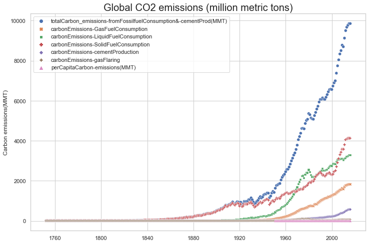

```python
sns.set(style="whitegrid")
fig, ax = plt.subplots(figsize=(12, 8))
index= duplicate.index.values
wide_df = pd.DataFrame(duplicate, index, ['totalCarbon_emissions-fromFossilfuelConsumption&-cementProd(MMT)',
       'carbonEmissions-GasFuelConsumption','carbonEmissions-LiquidFuelConsumption','carbonEmissions-SolidFuelConsumption',
       'carbonEmissions-cementProduction', 'carbonEmissions-gasFlaring','perCapitaCarbon-emissions(MMT)'])
ax.set_ylabel('Carbon emissions(MMT)')
ax.set_title('Global CO2 emissions (million metric tons)',fontsize=20)
sns.scatterplot(data=wide_df,ax=ax)
```

### Analysis

- global CO2 emissions are on the rise.
- CO2 emissions are at record speed over past decades.
- The amount of carbon dioxide in the atmosphere has increased since the Industrial Revolution.
- The largest contributer of CO2 emissions on earth's surface are Fossil fuels.

### Growth of global Fossil fuels consumption

```python
new1= climate[['totalCarbon_emissions-fromFossilfuelConsumption&-cementProd(MMT)']]
new1_df = pd.pivot_table(new1, index=new1.index.year)
new1_df.head()
```

| Time | totalCarbon_emissions-fromFossilfuelConsumption&-cementProd(MMT) |
| --- | --- |
| 1751 | 3.0 |
| 1752 | 3.0 |
| 1753 | 3.0 |
| 1754 | 3.0 |
| 1755 | 3.0 |

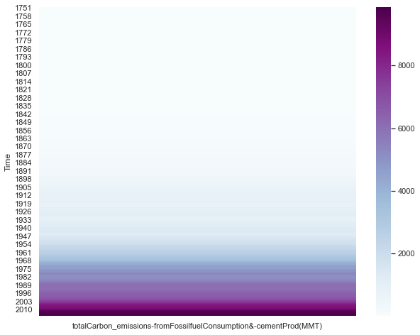

```python
plt.figure(figsize=(10, 8))
sns.heatmap(new1_df,cmap="BuPu")
```

We can overview the rate at which fossil fuels consumption has grown globally which emits large amount of CO2 into the atmosphere.

There seems to be steady growth in consumption of fossil fuels from 1960 to 2015.

### Global mean sea levels over years

```python
df=climate[['gmsl(mm)']]
df1 = pd.pivot_table(df, index=df.index.year, columns=df.index.month)
df1.head()
```

| Time | gmsl(mm) 1 | gmsl(mm) 2 | gmsl(mm) 3 | gmsl(mm) 4 | gmsl(mm) 5 | gmsl(mm) 6 | gmsl(mm) 7 | gmsl(mm) 8 | gmsl(mm) 9 | gmsl(mm) 10 | gmsl(mm) 11 | gmsl(mm) 12 |
| --- | --- | --- | --- | --- | --- | --- | --- | --- | --- | --- | --- | --- |
| 1880 | NaN | NaN | NaN | NaN | -158.7 | -158.7 | -158.7 | -158.7 | -158.7 | -158.7 | -158.7 | -158.7 |
| 1881 | -158.7 | -158.7 | -158.7 | -158.7 | -153.1 | -153.1 | -153.1 | -153.1 | -153.1 | -153.1 | -153.1 | -153.1 |
| 1882 | -153.1 | -153.1 | -153.1 | -153.1 | -169.9 | -169.9 | -169.9 | -169.9 | -169.9 | -169.9 | -169.9 | -169.9 |
| 1883 | -169.9 | -169.9 | -169.9 | -169.9 | -164.6 | -164.6 | -164.6 | -164.6 | -164.6 | -164.6 | -164.6 | -164.6 |
| 1884 | -164.6 | -164.6 | -164.6 | -164.6 | -143.7 | -143.7 | -143.7 | -143.7 | -143.7 | -143.7 | -143.7 | -143.7 |

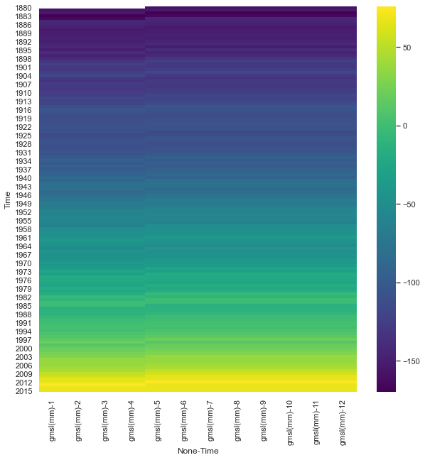

```python
plt.figure(figsize=(10, 10))
sns.heatmap(df1, cmap="viridis")
```

### Analysis

- This heatmap shows clearly that global sea levels are rising over the years.

### Variation of Land and Ocean temperatures on global sea levels over time

```python
# datetime indexing on duplicate dataframe
max_sam= duplicate['1850-12-31':'1890-12-31']
sam2= duplicate['1891-12-31':'1931-12-31']
sam3= duplicate['1932-12-31':'1972-12-31']
sam4= duplicate['1973-12-31':'2015-12-01']

# creating dataframes by using above indices with columns
a=max_sam[['gmsl(mm)']]
b=max_sam[['Land&OceanAvgTemp']]
c=sam2[['gmsl(mm)']]
d=sam2[['Land&OceanAvgTemp']]
e= sam3[['gmsl(mm)']]
f= sam3[['Land&OceanAvgTemp']]
g= sam4[['gmsl(mm)']]
h= sam4[['Land&OceanAvgTemp']]
```

Here we prepared the data for us to use to plot and see relationship between Land and Ocean temperatures and Global mean sea levels.

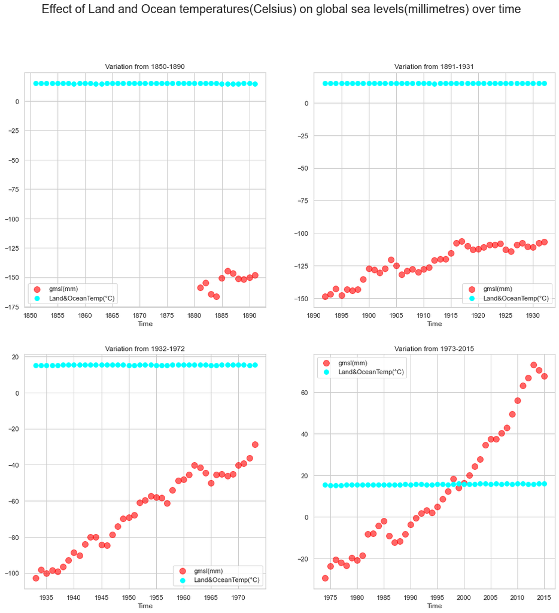

```python
sns.set(style="whitegrid")
# 4 subplots figure size
fig,axs= plt.subplots(2,2,figsize=(16, 16))
# setting main title
plt.suptitle("Effect of Land and Ocean temperatures(Celsius) on global sea levels(millimetres) over time", fontsize=20)
# Add x-axis and y-axis
axs[0,0].scatter(a.index, a,s=100,alpha=.6 ,color='red')
axs[0,0].scatter(b.index, b, s=60,color='cyan')
axs[0,1].scatter(c.index, c,s=100,alpha=.6 ,color='red')
axs[0,1].scatter(d.index, d, s=60,color='cyan')
axs[1,0].scatter(e.index, e,s=100,alpha=.6 ,color='red')
axs[1,0].scatter(f.index, f, s=60,color='cyan')
axs[1,1].scatter(g.index, g,s=100,alpha=.6 ,color='red')
axs[1,1].scatter(h.index, h, s=60,color='cyan')

# set x,y label , title and legend
axs[0,0].set_xlabel('Time')
axs[0,0].legend(['gmsl(mm)', 'Land&OceanTemp(°C)'])
axs[0,0].set_title('Variation from 1850-1890')
axs[0,1].set_xlabel('Time')
axs[0,1].legend(['gmsl(mm)', 'Land&OceanTemp(°C)'])
axs[0,1].set_title('Variation from 1891-1931')
axs[1,0].set_xlabel('Time')
axs[1,0].legend(['gmsl(mm)', 'Land&OceanTemp(°C)'])
axs[1,0].set_title('Variation from 1932-1972')
axs[1,1].set_xlabel('Time')
axs[1,1].legend(['gmsl(mm)', 'Land&OceanTemp(°C)'])
axs[1,1].set_title('Variation from 1973-2015')

# show plot
plt.show()
```

Changing climate is affecting the ocean and global sea level has been steadily rising since 1900, we can see that in above graph.

- The ocean temperatures are rising and as oceans warm due to the increasing temperature, seawater expands- causing a rise in water level.
- This rising of Land and Ocean Temperatures are great dangers to our coastal areas as sea level rises.
- As the oceans have heated up, they gets bigger and sea levels creep up.

### Land Average temperature, maximum temperature and minimum temperature

Let's get to know if Land average temperatures, Land maximum temperatures and Land minimum temperatures are rising over the years:

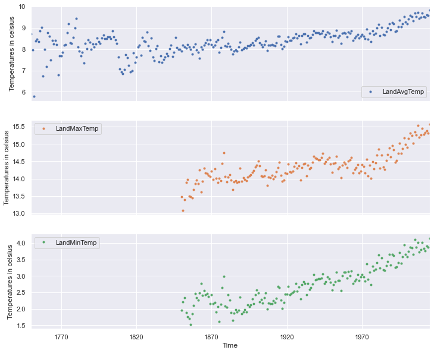

```python
sns.set(rc={'figure.figsize':(12, 10)})
# plot the desired columns
cli_plot = ['LandAvgTemp','LandMaxTemp', 'LandMinTemp']
axes = duplicate[cli_plot].plot(marker='.', linestyle='None', subplots=True)
for ax in axes:
    ax.set_ylabel('Temperatures in celsius')
```

Here we used plot() method of Dataframe to plot multile columns. The plot method creates a basic line plot from a data frame or series. Above we see:

### More hot months and fewer cold months since 1950

```python
# 100 most coldest months
a=climate.sort_values('LandMinTemp').head(100)
# Top 100 hot months
b=climate.sort_values('LandMaxTemp',ascending=False).head(100)
# checking index in series object
cold_m =a.LandMinTemp.index>='1950-01-01'
# Unique values & their frequency count from a Numpy array
np.unique(cold_m, return_counts=True)
```

```
(array([False,  True]), array([95,  5], dtype=int64))
```

Now, here we can see that in 100 top months with Minimum temperature in climate data; we can infer that there are very few cold months since 1950s. So this can mean that Global temperatures have gone up.

```python
# hot months since 1950
hot_m =b.LandMaxTemp.index>='1950-01-01'
# Unique values & their frequency count from a Numpy array
np.unique(hot_m, return_counts=True)
```

```
(array([False,  True]), array([35, 65], dtype=int64))
```

This can conclude that hotter months are far greater in number than cold months since 1950s that it had been in the past years. This may be a sign that the Earth really is getting warmer and it’s the rise in average temperature of the Earth's climate system since the past century that can't be neglected.

### Does the rise in average temperature related to global higher temperatures?

As we have seen above earth experiences more hot months than cold months and earth's climatic atmosphere might be a big part of how the temperatures are fuctuating around the clock. We can put global average temperature and Maximum and Minimum temperatures sise by side to get some interesting observations.

Now to estimate the relationship between earth's average temperature with high or low temperatures we will use the regression plots available in seaborn library as a visual guide that may help us to emphasize patterns in the data. This type of plot can be used when to determine a relationship as determined through regression. This method is used to plot data and a linear regression model fit. sns.regplot() draw a scatterplot of two variables, x(the independent variable) and y(dependent variable), and then fit the regression model and plot the resulting regression line and a 95% confidence interval.

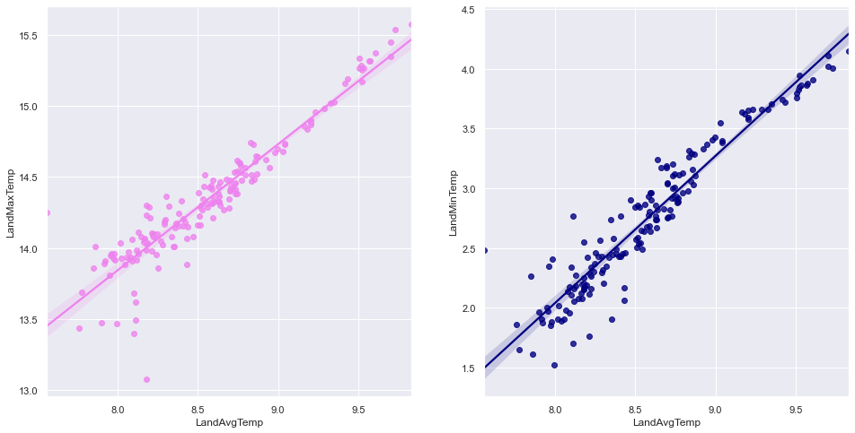

```python
sns.set(style="darkgrid")
# 2 subplots on 1 axis with defined figure size
f, ax = plt.subplots(1,2,figsize=(16,8))
# regression model plot
sns.regplot(x="LandAvgTemp", y="LandMaxTemp", data=duplicate, ax=ax[0], color='violet')
sns.regplot(x="LandAvgTemp", y="LandMinTemp", data=duplicate, ax=ax[1], color='navy')
```

We may see the planet’s temperature are changing and it's somewhere related to the rise in average temperature of the Earth's climate system. Thus this temperature rise or warming of the Earth's surface will result in hot atmosphere around the globe as it's known that the global average temperatures are rising, making earth warmer and average temperatures higher.

### Hottest Year on Record

```python
# sorting LandAvgTemp and Land&OceanAvgTemp by yearly time period
year=duplicate.sort_values('LandAvgTemp',ascending=False).head(1)
year_x=duplicate.sort_values('Land&OceanAvgTemp',ascending=False).head(1)
# checking year index
year.LandAvgTemp.index
year_x['Land&OceanAvgTemp'].index
```

```
DatetimeIndex(['2015-12-31'], dtype='datetime64[ns]', name='Time', freq=None)
```

### Analysis

- Rising global temperatures at record speed in the past few decades might be the cause that 2015 has been the hottest year on record of earth.

### Hottest Decade on Record?

```python
duplicate1= duplicate.resample('10A').mean()
```

To check the warmest decade we can resample the duplicate time series dataset per decades which is more helpful in this case. The '10A' specifies that we want to aggregate, or resample, by decade.

```python
# sorting LandAvgTemp by decade and checking index
dec= duplicate1.sort_values('LandAvgTemp',ascending=False).head(2)
dec.LandAvgTemp.index
```

```
DatetimeIndex(['2020-12-31', '2010-12-31'], dtype='datetime64[ns]', name='Time', freq=None)
```

```python
# sorting Land&OceanAvgTemp by decade and checking index
dec1= duplicate1.sort_values('Land&OceanAvgTemp',ascending=False).head(2)
dec1.LandAvgTemp.index
```

```
DatetimeIndex(['2020-12-31', '2010-12-31'], dtype='datetime64[ns]', name='Time', freq=None)
```

### Are global sea levels rising?

We will find that if Global sea level has been rising and at what rate the level is increasing in decades.

```
1880-12-31 00:00:00
```

[figure not shown]

```python
dec_gmsl= duplicate1[['gmsl(mm)']]
# checking for not null values
print(dec_gmsl['gmsl(mm)'].first_valid_index())
# not accounting for Nan values
idx = dec_gmsl['1880-12-31': ]

sns.set(style="whitegrid")
# configuring the figure size
fig,ax = plt.subplots(figsize=(10, 10))
# barchart plotting
idx['gmsl(mm)'].plot.bar(color='royalblue')
# setting the y label
ax.set_ylabel('Global sea levels in millimeters')
ax.xaxis.set_major_formatter(mdates.DateFormatter('%Y'))
# title setting
ax.set_title('Rise of sea levels over decades',fontsize=20)
```

### Analysis

Bar charts are used to display values associated with categorical data. Above we categorised the time periods as decades and then plotted bars representing Global sea levels in millimetres for each decade from timeseries data('duplicate1').

- The Oceans are changing. Above observations shows that the ocean has been changing over the last several decades and the rate has increased in recent decades. Sea-level rise is a response to increasing changes in the global climate and coastal regions at most risk including heavily populated deltaic regions, small islands.

### Is ocean warming real? If true then show temperatures per decade over the past 100 years

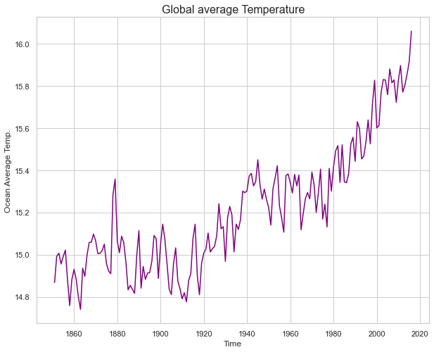

```python
sns.set(style="whitegrid")
fig, ax = plt.subplots(figsize=(10, 8))

# Add x-axis and y-axis
ax.plot(duplicate.index.values,duplicate['Land&OceanAvgTemp'],color='purple')

# Set title and labels for axes
ax.set(xlabel="Time", ylabel="Ocean Average Temp.")
ax.set_title("Global average Temperature", fontsize=16)
plt.show()
```

### Analysis

To plot this figure we used duplicate dataset as it is more helpful to use annual average ocean temperatures in this context otherwise by using monthly average ocean temperatures for this range of years would give us undesired results.

Here it is clear the ocean is absorbing most of the heat, leading to rising ocean temperatures. Increasing ocean temperatures affect marine species and ecosystems and also affect the benefits humans derive from the ocean.

[figure not shown]

```python
# slicing index for last 100 years
idx = duplicate1['1920-12-31': ]
sns.set(style="darkgrid")
# configuring the figure size
fig,ax = plt.subplots(figsize=(8, 6))
# barchart plotting
idx['Land&OceanAvgTemp'].plot.bar(color='brown')
# setting the y label
ax.set_ylabel('Global ocean temperature in celsius')
ax.xaxis.set_major_formatter(mdates.DateFormatter('%Y'))
# title setting
ax.set_title('Ocean temperatures of last 100 years',fontsize=16)
```

```python
m = duplicate1[['Land&OceanAvgTemp']].mean()
final= duplicate1[['Land&OceanAvgTemp']]-m
final[-5:]
```

| Time | Land&OceanAvgTemp |
| --- | --- |
| 1980-12-31 | 0.091243 |
| 1990-12-31 | 0.246010 |
| 2000-12-31 | 0.382751 |
| 2010-12-31 | 0.600626 |
| 2020-12-31 | 0.665743 |

### Analysis

Land and Ocean Surface Temperature data are presented above as anomalies (departures from a long-term average) that is what needed to do more meaningful comparisons and more accurate calculations of temperature for last century. A temperature anomaly is the difference from an average, or baseline, temperature. The baseline temperature is typically computed by averaging 30 or more years of temperature data. In this case temperature anomalies are more important than absolute temperatures.

To find anomaly of Land and Ocean Surface Temperatures we subracted long term average of absolute temperatures from decade time period.

```python
# Increase in ocean temperature
# temp. at 2020 subracted by 100 year's average
final['Land&OceanAvgTemp']['2020-12-31']-final.mean()
```

```
Land&OceanAvgTemp    0.665743
dtype: float64
```

### Annual Per capita CO2 emissions

Per capita Emissions is a measure of carbon emissions per person in each country. But in this context they are annual global Per capita emissions.

[figure not shown]

```python
sns.set(style="whitegrid")
# configuring the figure size
fig,ax = plt.subplots(figsize=(15, 5))
# create series with desired indexing
ide = duplicate['perCapitaCarbon-emissions(MMT)']['1950-12-31':]
# barchart plotting
ide.plot.bar(color='tomato')
# setting the y label
ax.set_ylabel('Per capita CO2 emissions')
ax.xaxis.set_major_formatter(mdates.DateFormatter('%Y'))
# title setting
ax.set_title('Per capita CO2 emissions(MMT) from 1950',fontsize=16)
```

### Total carbon footprint

A carbon footprint is the amount of greenhouse gases—primarily carbon dioxide—released into the atmosphere by the activities of a particular individual, organization, or community.

```python
# sum of annual carbon emissions from dataset from different sources
# tuple type to List
car_fp= (411923.0, 57043.0, 144945.0, 194604.0, 11583.0, 3756.0, 70.8)

# total carbon emissions from all sources
print('Total atmospheric concentrations of Carbon :', sum(car_fp),'million metric tons')
```

```
Total atmospheric concentrations of Carbon : 823924.8 million metric tons
```

The sum() function adds the items of an iterable and returns the sum. Here we computed total carbon emitted into the earth's atmosphere.

### Carbon emissions from 2000 to 2010 from different sources

```python
car_dec= duplicate['2000-12-31':'2010-12-31']
print("Carbon emissions (million metric tons) from different Sources for 2000's:-")
# A new line character
print('')
# cumulative sum of carbon emissions for sectors
print('Fossil fuels and cement production:',
     car_dec['totalCarbon_emissions-fromFossilfuelConsumption&-cementProd(MMT)'].sum())
print('Gas Fuel Consumption:', car_dec['carbonEmissions-GasFuelConsumption'].sum())
print('Cement Production:', car_dec['carbonEmissions-cementProduction'].sum())
print('Liquid Fuels:', car_dec['carbonEmissions-LiquidFuelConsumption'].sum())
print('Gas Flaring:', car_dec['carbonEmissions-gasFlaring'].sum())
print('Solid Fuels:', car_dec['carbonEmissions-SolidFuelConsumption'].sum())
print('Per capita emissions:', car_dec['perCapitaCarbon-emissions(MMT)'].sum())
```

```
Carbon emissions (million metric tons) from different Sources for 2000's:-

Fossil fuels and cement production: 87221.0
Gas Fuel Consumption: 16278.0
Cement Production: 3596.0
Liquid Fuels: 33008.0
Gas Flaring: 634.0
Solid Fuels: 33703.0
Per capita emissions: 13.330000000000002
```

### Analysis

We see from 2000 to 2010,

- fossil fuels produced more carbon than any other sector.
- Than Liquid and solid fuels are the biggest contributer to carbon emissions.
- Per capita cabon emissions are lowest when compared to other sectors.

### Surface maximum and minimum temperature over 5 years

```python
duplicate1.sort_values('LandMaxTemp', ascending=False).head(1)
```

| Time | LandAvgTemp | LandMaxTemp | LandMinTemp | Land&OceanAvgTemp | gmsl(mm) | totalCarbon_emissions-fromFossilfuelConsumption&-cementProd(MMT) | carbonEmissions-GasFuelConsumption | carbonEmissions-LiquidFuelConsumption | carbonEmissions-SolidFuelConsumption | carbonEmissions-cementProduction | carbonEmissions-gasFlaring | perCapitaCarbon-emissions(MMT) |
| --- | --- | --- | --- | --- | --- | --- | --- | --- | --- | --- | --- | --- |
| 2020-12-31 | 9.6063 | 15.37555 | 3.90435 | 15.879567 | 69.166667 | 9731.8 | 1798.2 | 3222.8 | 4104.2 | 540.6 | 66.6 | 1.36 |

```python
duplicate1.sort_values('LandMinTemp').head(1)
```

| Time | LandAvgTemp | LandMaxTemp | LandMinTemp | Land&OceanAvgTemp | gmsl(mm) | totalCarbon_emissions-fromFossilfuelConsumption&-cementProd(MMT) | carbonEmissions-GasFuelConsumption | carbonEmissions-LiquidFuelConsumption | carbonEmissions-SolidFuelConsumption | carbonEmissions-cementProduction | carbonEmissions-gasFlaring | perCapitaCarbon-emissions(MMT) |
| --- | --- | --- | --- | --- | --- | --- | --- | --- | --- | --- | --- | --- |
| 1850-12-31 | 7.988542 | 13.476667 | 1.964333 | 14.867167 | NaN | 42.9 | 0.0 | 0.0 | 42.9 | 0.0 | 0.0 | NaN |

Above we checked time of highest maximum temperature on earth and also the lowest minimum temperature globally.

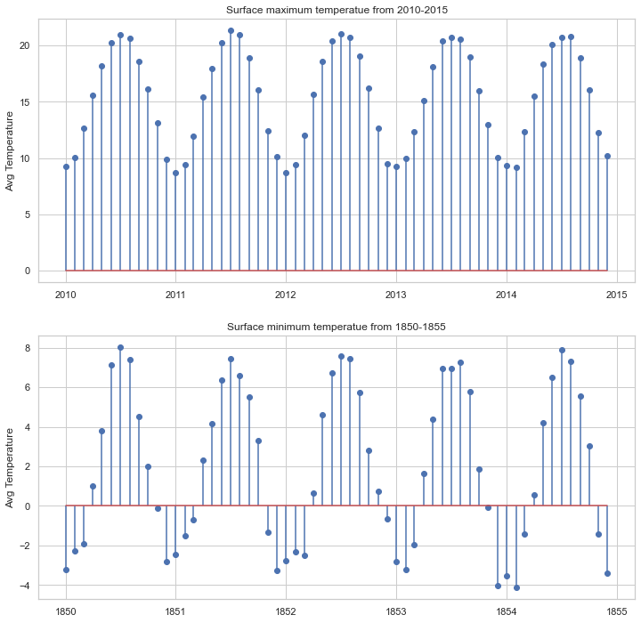

```python
fig,(ax1,ax2) = plt.subplots((2),figsize=(12, 12))
# data to plot
data=climate['2010-01-01':'2014-12-31']
data1= climate['1850-01-01':'1854-12-31']
# Add x-axis and y-axis
x=data.index.values
y=data['LandMaxTemp']
x1=data1.index.values
y1= data1['LandMinTemp']
# plot
ax1.stem(x, y,use_line_collection=True)
ax2.stem(x1, y1,use_line_collection=True)
# set labels and title
ax1.set_ylabel('Avg Temperature')
ax2.set_ylabel('Avg Temperature')
ax1.set_title('Surface maximum temperatue from 2010-2015')
ax2.set_title('Surface minimum temperatue from 1850-1855')
# show plot
plt.show()
```

### Analysis

Stem plot is used to plot vertical lines from the baseline to the y-coordinate and places a marker at the tip.

- In this plot we see that maximum surface temperature reaches its peak at the middle of the year, particularly in July and therefore 'July' can be considered to be the consecutive hottest month from 2010 to 2015.
- And in minimum land temperature from 1850 to 1855 the earth experiences lowest temperatures; the temperature dropping lowest at the start and end of the year.

## Asking and Answering Questions

#### Q1: How much global average surface temperature has increased since 1880?

To find the increase in surface temperature we need to compute the temperature anomalies to get the desired results. Temperature anomalies are more important than absolute temperature in this case. A temperature anomaly is the difference from an average, or baseline, temperature. The baseline temperature is typically computed by averaging 30 or more years of temperature data.

```python
# Indexing and create dataframe for needed time period
anom= duplicate[['LandAvgTemp']]['1880-12-31':]
anom['1950-12-31':'1980-12-31'].mean()
```

```
LandAvgTemp    8.648513
dtype: float64
```

We will use mean of 1951-1980 average temperatures as the baseline temperature to calculate the anomaly or the change in global surface temperature relative to 1951-1980 average temperatures.

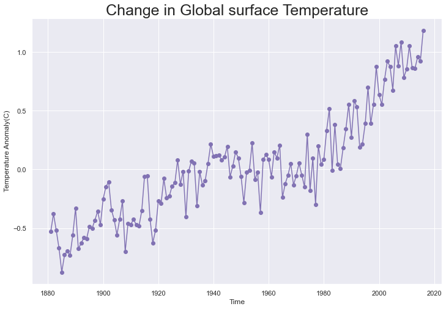

```python
# finding the temperatures anomaly
anom_temp= anom-8.648513
sns.set(style="darkgrid")
# set figure size
fig, ax = plt.subplots(figsize=(12, 8))
# Add x-axis and y-axis
ax.plot(anom_temp.index, anom_temp['LandAvgTemp'], 'mo-')
# Set title and labels for axes
ax.set(xlabel="Time", ylabel=" Temperature Anomaly(C)")
ax.set_title("Change in Global surface Temperature", fontsize=25)
# show plot
plt.show()
```

Above the plot shows the change in global surface temperature relative to 1951-1980 average temperatures and we can see the Earth’s average surface temperature has been steadily increasing since 1880. The effets could be drastic if this trend of global warming continues. We can also infer that change in temperature is somewhere around 1° Celsius.

```python
anom['2000-12-31':'2015-12-31'].mean()
```

```
LandAvgTemp    9.542094
dtype: float64
```

### Analysis

- The global temperature record represents an average over the entire surface of the planet. This degree increase in global average surface temperature that has occurred since industrial era might seem small, but it means a significant increase in accumulated heat and it can result to rising sea levels with the consequent loss of land, floods and droughts, disease continuing to spread such as malaria and other major prpblems.
- There is a great need to reduce global warming.

#### Q2: Is sea level rising? If yes then show change in global sea levels

```
1880-12-31 00:00:00
```

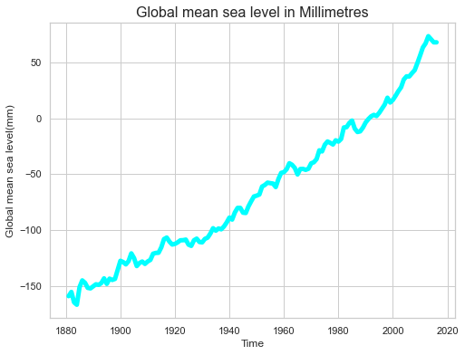

```python
print(duplicate['gmsl(mm)'].first_valid_index())
ind= duplicate[['gmsl(mm)']]['1880-12-31':]

sns.set(style="whitegrid")
fig, ax = plt.subplots(figsize=(8, 6))
# Add x-axis and y-axis
ax.plot(ind.index.values,ind['gmsl(mm)'],color='cyan',linewidth=5)
# Set title and labels for axes
ax.set(xlabel="Time", ylabel="Global mean sea level(mm)")
ax.set_title("Global mean sea level in Millimetres", fontsize=16)
plt.show()
```

### Analysis

Yes, sea level is rising at an increasing rate.

We can see global sea level has been rising since 1880, and the rate at which the sea level is rising is not slowing down. To find the rate of change of global sea levels we need to calculate Sea level anomaly. A sea-level anomaly is the difference between the total sea-level and the average sea-level for time of year.

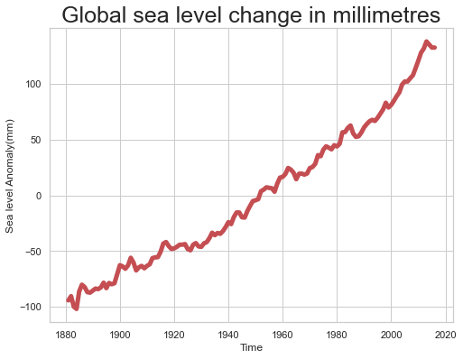

```python
# sea level anomaly
# average of time period
y= ind['gmsl(mm)'].mean()
# change in sea levels
ind= ind[['gmsl(mm)']]-y

sns.set(style="whitegrid")
# set figure size
fig, ax = plt.subplots(figsize=(8, 6))
# Add x-axis and y-axis
ax.plot(ind.index, ind['gmsl(mm)'], 'r-', linewidth=5)
# Set title and labels for axes
ax.set(xlabel="Time", ylabel="Sea level Anomaly(mm)")
ax.set_title("Global sea level change in millimetres", fontsize=25)
# show plot
plt.show()
```

### Analysis

The graph above tracks the change in sea level since 1880 as the sea levels are continuously rising. Higher sea levels mean that deadly and destructive storms and flooding. Ocean sea levels are changing over time. WWhen sea levels rise as rapidly as they have been, then its a threat to everyone and virtually all human infrastructure—is at risk from sea level rise.

#### Q3: Main sources of Carbon emissions

```python
# finding total cabon emissions from different sources
a= duplicate['totalCarbon_emissions-fromFossilfuelConsumption&-cementProd(MMT)'].sum()
b= duplicate['carbonEmissions-GasFuelConsumption'].sum()
c= duplicate['carbonEmissions-cementProduction'].sum()
d= duplicate['carbonEmissions-LiquidFuelConsumption'].sum()
e= duplicate['carbonEmissions-gasFlaring'].sum()
f= duplicate['carbonEmissions-SolidFuelConsumption'].sum()
g= duplicate['perCapitaCarbon-emissions(MMT)'].sum()
a,b,c,d,e,f,g
```

```
(411923.0, 57043.0, 11583.0, 144945.0, 3756.0, 194604.0, 70.8)
```

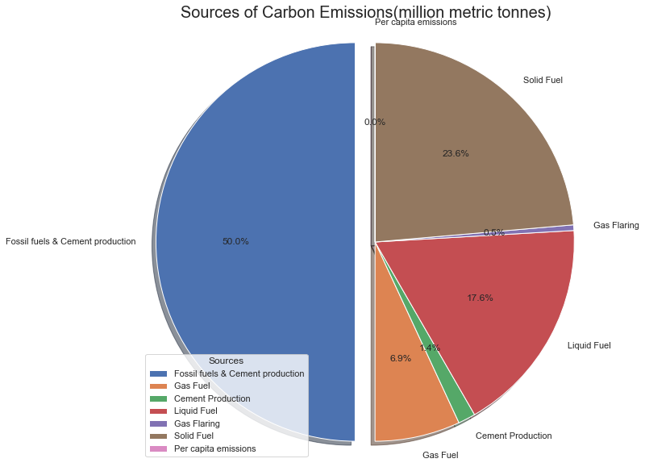

```python
fig1, ax1 = plt.subplots(figsize=(10,10))
# Creating dataset
labels = ['Fossil fuels & Cement production', 'Gas Fuel', 'Cement Production', 'Liquid Fuel', 'Gas Flaring', 'Solid Fuel',
'Per capita emissions']
sums = [411923.0, 57043.0, 11583.0, 144945.0, 3756.0, 194604.0, 70.8]
# explode data
# "explode" the 1st slice
explode = (0.1, 0, 0, 0, 0, 0, 0)
# plotting pie chart
ax1.pie(sums, explode=explode, labels=labels,  autopct='%1.1f%%',shadow=True, startangle=90)
# Add legend
ax1.legend(labels, title ="Sources",loc ="lower left")
# Set title
ax1.set_title("Sources of Carbon Emissions(million metric tonnes)", fontsize=20)
# Equal aspect ratio ensures that pie is drawn as a circle
ax1.axis('equal')
# show plot
plt.show()
```

### Analysis

We can make some interesting insights about carbon emissions from different sources on earth.

- Almost half of the carbon emissions around the globe till now are produced by Fossil fuels & Cement production.
- After Fossil fuels & Cement production, Solid Fuels, Liquid Fuels and Gas Fuel are the biggest contributers of carbon emissions.
- Cement production and Gas flaring emits low carbon into the atmosphere.
- Per capita carbon emissions are the lowest of all.

#### Q4: Ocean's rate of heating?

As we already know ocean temperatures are rising and oceans are warming faster at record speed. We can calculate the average global sea surface temperatures – rate of change or also referred to as 'Sea Surface Temperature Anomaly'.

```python
duplicate['Land&OceanAvgTemp'].first_valid_index()
```

```
Timestamp('1850-12-31 00:00:00', freq='A-DEC')
```

```python
oce= duplicate[['Land&OceanAvgTemp']]['1880-12-31':]
# mean of 1980-2010 average temperatures
v= oce['1980-12-31':'2009-12-31'].mean()
# finding the temperatures anomaly
oce_temp= oce-v
```

We will use mean of 1980-2009 average ocean temperatures as the baseline temperature to calculate the anomaly.

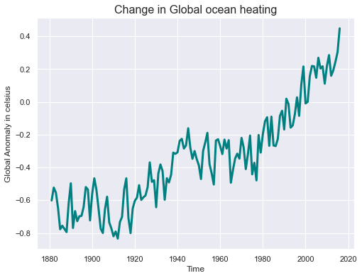

```python
sns.set(style="darkgrid")
fig, ax = plt.subplots(figsize=(8, 6))
# Add x-axis and y-axis
ax.plot(oce_temp.index.values,oce_temp['Land&OceanAvgTemp'],color='teal',linewidth=3)
# Set title and labels for axes
ax.set(xlabel="Time", ylabel="Global Anomaly in celsius")
ax.set_title("Change in Global ocean heating", fontsize=16)
plt.show()
```

### Analysis

- Above plot describes global trends in sea surface temperature are rising at rate of change between 0.4 celsius.

```python
# value to compute rate of change
rc = oce['Land&OceanAvgTemp']['2015-12-31']
rc
```

```
16.058583333333335
```

```python
# finding the increase in temperature
z= rc-v
# rounding
print(round(z, 2))
```

```
Land&OceanAvgTemp    0.45
dtype: float64
```

### Analysis

- Here we can conclude that the rate of change of warming of ocean water is around 0.45° Celsius from baseline average ocean temperatures from 1980-2009.
- This rise in ocean temperatures are raising global sea level because water expands when it warms. This trend of rising temperatures, combined with water from melting glaciers on land, the rising sea threatens natural ecosystems and human structures near coastlines around the world. Finally, warming ocean waters threaten marine ecosystems and human livelihoods.

## Inferences and Conclusion

Certain gases in the atmosphere block heat from escaping which results in heating of earth's surface. This is referred as "greenhouse effect" and this greenhouse effect attributes to the Global warming. Now one of the most important gas that contribute to the greenhouse effect is Carbon dioxide (CO2); over the last century the burning of fossil fuels, consumption of Solid and Liquid fuels has increased the carbon emissions at the unprecedented rate. It can be said that this greenhouse gas is the main driver of 'global warming'.

'Global warming' is causing the earth’s atmosphere to become warmer and global temperatures are rising at record speed in the past few decades than known in the past. Greenhouse effect is warming the ocean too, increasing the sea level. Ocean water expands if it warms, contributing further to sea level rise. Elevated CO2 levels are changing temperatures around the world.

Ocean temperature is rising as the ocean absorbs excess heat from greenhouse gas emissions which also leads to rising sea levels. Increasing ocean temperatures affect marine species and ecosystems and causing more extreme weather events and the loss of coastal protection. Ocean warming leading to sea-level rise often results from the thermal expansion of sea water and continental ice melting. Rising sea levels can affect low-lying island countries in the Ocean.

The earth has experienced more hot months all occurring in the past few decades. Temperature anomalies, or changes, depicts how much world have warmed or cooled when compared with a base period of 1951-1980. The strong warming trend of the past few decades is accelerating the rate of sea level rise. All at risk from sea level rise, coastlines around the world, infrastructure and regional industries. Burning of fossil fuels releases more CO2 than any other source into the earth’s atmosphere and which links to ‘Global warming’. Planet is heating up, causing global average temperatures to rise which is leading to higher sea levels.